# Day 7: Which model when? The frontier

- Show All Code
- Hide All Code
- View Source

Advanced Network Analysis · ICPSR

Author

Shahryar Minhas

Published

July 22, 2026

**NoteHow to use this document**

Open the Day 7 teaching deck.

Everything in here runs. There is no separate script; this *is* the script, with the reasoning left in. Read it top to bottom in class; re-run any chunk against the warm cache afterwards and you will get the same numbers, because everything is seeded at `6886`.

The expensive fits are wrapped in `cache_fit()`, which stores them in `cache/`. The first person to run a chunk pays for the fit (nothing today is worse than ~30 seconds cold); everyone after loads it in milliseconds. Delete `cache/` to force honest refits of everything.

Four packages appear today for the first time; `relevent` and `goldfish` for the relational-event segment (both on CRAN, both compiled cleanly on the course machine), and `dbn` and `sir` for the tensor and influence segments (both from my own shop’s GitHub); `lame` and `dcr` come from GitHub too, exactly as on their own days:

```r
install.packages(c("netify", "blockmodels", "ergm", "network",
                   "relevent", "goldfish", "ggplot2", "ggrepel",
                   "coda", "digest", "remotes",
                   "multiwayvcov"))   # dcr calls this but does not
                                      # declare it; Day 6's install
                                      # trap; without it dcr() errors
remotes::install_github("s7minhas/lame")
remotes::install_github("jscarlson/dcr")    # Dyadic cluster-robust SEs
remotes::install_github("netify-dev/dbn")   # Dynamic bilinear network models
remotes::install_github("netify-dev/sir")   # Social influence regression
```

**Where this day sits on the map.** It doesn’t pick a cell; it runs the whole map. The syllabus promised, as its first objective, that you would “develop an ability to compare the relative merits of the various models covered for a given empirical application.” Today is where that promise is kept: one dataset through every lens this course built, a decision framework you can carry out of the room, and an honest tour of what exists beyond the seven days.

**NoteToday’s path**

| Segment |
| --- |
| The question that outlasts the course |
| One dataset: the rebel-cooperation network, third pass |
| Lens 0: the GLM, and calibrated standard errors |
| Lens 1: the SRM: where does the actor dependence live? |
| Lens 2: the blockmodel: do actors come in kinds? |
| Lens 3: AME: geometry on top of the covariates |
| Lens 4: the ERGM: is closure a mechanism? |
| The payoff table: one network, every lens |
| The decision framework |
| The frontier: relational event models, live |
| The frontier: the tensor lane (DBN, live) |
| The frontier: influence: who moves whom (SIR, live) |
| The frontier: multilayer and bipartite networks |
| The frontier: scale, and the adjacent field |
| The frontier: the econometrics of networks |
| Close: the map, filled in |
| Your turn |
| Reading |

If you are short on time, segments 8, 9, and 10 are the ones you cannot skip: the payoff table is the course’s argument in one screen, the framework is the thing you will actually use next year, and the REM demo is the one genuinely new estimator of the day.

# 1 The question that outlasts the course

Six days ago the course opened with a claim: *dyadic observations are not independent, and every method we teach is a different decision about where to put the dependence.* Since then you have represented it with latent effects three ways (additive effects, discrete blocks, continuous geometry), in the model itself (the ERGM), across time (the SAOM), and into the standard errors (dyadic cluster-robust inference). Each day ended by pointing at the next cell of the map.

Today there is no next cell. Today is the question you will actually face the week you get home:

> **I have network data and a question. What do I fit?**

Notice the order. The data does not pick the model, and neither does your discipline’s habit. *The question picks the model*, and the single most common error in applied network work is answering a measurement question with a dependence-correction tool, or a mechanism question with a descriptive one, and not noticing.

So today has three movements:

1. **One dataset, every lens.** We take a network you have now seen twice (the Syrian rebel cooperation data) and run it through the entire toolkit: GLM, dyadic-robust SEs, SRM, blockmodel, AME, ERGM. The same underlying network, covariates aligned where each family permits them, and one shared goodness-of-fit yardstick. The payoff is not “which model won.” The payoff is that they answer *different questions*, and you will watch them do it.
2. **The decision framework.** A flowchart and a table keyed to the course map. This is the artifact to screenshot.
3. **The frontier.** What exists beyond the seven days: relational event models (live, fitted in front of you), propagation and influence models (also live, with two estimands from my own shop), multilayer and bipartite networks, what happens at scale, what the machine-learning world does with the same objects, and the econometrics tradition next door, each with a named entry point so “go read about X” is an actionable sentence.

**ImportantThe one sentence of the day**

A model is a lens, not a truth: each one answers the question it was built for, and the honest move is to state your question first and pick the lens second.

## 1.1 How Each Estimator Learns From the Same Political Network

The rebel-cooperation data will not change across the first five lenses, but the algorithms treat it as different statistical evidence.

| Lens | What the estimator does | What moves during estimation |
| --- | --- | --- |
| GLM | Maximizes a dyad-level likelihood | Regression coefficients |
| GLM with DCR | Keeps the GLM fit and rebuilds its covariance matrix | Standard errors and intervals, not coefficients |
| SRM | Uses MCMC to learn covariate coefficients, sender and receiver effects, variance components, and reciprocity jointly | Conditional mean and uncertainty |
| Blockmodel | Alternates approximate membership updates with block-to-block probability updates | Actor membership probabilities and mixing matrix |
| AME | Uses MCMC to learn additive actor effects and a low-rank relational surface | Conditional mean, latent surface, and uncertainty |
| ERGM | Uses network simulation inside maximum likelihood to match observed graph statistics | Coefficients on covariates and graph configurations |

That table explains why the coefficient on the same covariate can move. The models are not merely applying different standard errors to one fixed regression. Most of them rebuild the conditional mean around a different representation of network dependence.

For every lens, we will follow the same sequence:

1. Name the political science question that motivates the lens.
2. State the estimand or conditional association.
3. Identify the unit of statistical information.
4. Walk through what the estimator updates and what it holds fixed.
5. Read the coefficient in the model’s own conditional language.
6. Check the feature that would make us abandon or expand the model.

### 1.1.1 The Applied Compass, in Human Language

[output not shown]

If we cannot complete the right-hand sentence without hiding behind the package vocabulary, we have not yet interpreted the model.

# 2 One dataset: The rebel-cooperation network, third pass

The data is from Gade, Gabbay, Hafez & Kelly (2019): cooperation among 30 rebel groups in the Syrian civil war. Abstractly: a **symmetric binary network**: actors either coordinated (joint operations, statements, resource sharing) or did not, with two nodal covariates (ideology score, group size) and four dyadic ones (ideological distance, power difference, shared location, shared sponsor).

You have met this network twice. On **Day 2** it was the falsification scorecard: a mixed-membership blockmodel missed its actor heterogeneity by about ten posterior-predictive standard deviations and the latent factor model rescued it. On **Day 6** it was the calibration case: the dyadic cluster-robust standard errors grew relative to the naive ones. Today it is the common ground every lens gets pointed at.

```r
load("data/gadeData.rda")          # A dyadic data.frame named `data`
data$coop <- as.numeric(data$coopActions > 0)

net <- netify(data, actor1 = "actor1", actor2 = "actor2",
              symmetric = TRUE, weight = "coop",
              nodal_vars = c("averageId_actor1", "size_actor1"),
              dyad_vars  = c("ideol_diff", "powerdiff", "loc", "spons"))
A <- as.matrix(net); diag(A) <- NA
```

The descriptive pass, the “describe it” cell of the map and Week 0’s lens, gets a nod rather than a lab because you did it with Olga and again on Day 1:

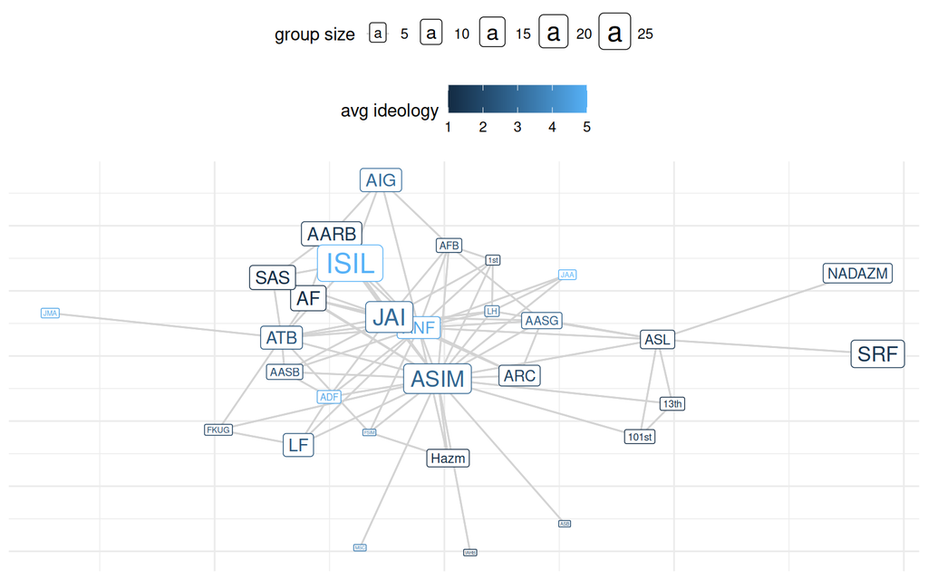

The rebel cooperation network. Label size is group size, color is average ideology. The visual story is the modeling story: a few very active hubs, a quiet periphery, and ties bunching among ideological kin.

```r
plot(net, edge_color = "lightgrey", add_points = FALSE,
     add_label = TRUE, label_color_var = "averageId_actor1",
     label_size_var = "size_actor1") +
  labs(color = "avg ideology", size = "group size")
```

```r
dens <- mean(A, na.rm = TRUE)
deg  <- rowSums(A, na.rm = TRUE)
```

Density is 0.195, of the 435 possible pairs, 85 cooperate. Degree runs from 1 to 25, and that spread is the single loudest feature of this network: ASIM cooperates with 25 others while 6 groups have two or fewer partners.

**The shared yardstick.** To hold every model to the same standard we reuse Day 2’s three GOF statistics, computed the same way for every lens: actor heterogeneity (`sd` of row means; do some actors tie far more than others?), and third-order cycle and transitivity dependence (is there triangle structure beyond chance?). Same function as Day 2, verbatim:

```r
calc_gof <- function(mat) {
  mat <- as.matrix(mat)
  actor_sd <- sd(rowMeans(mat, na.rm = TRUE), na.rm = TRUE)
  E <- mat - mean(mat, na.rm = TRUE)
  D <- 1 * (!is.na(E)); E[is.na(E)] <- 0
  s3 <- sd(c(mat), na.rm = TRUE)^3
  cycle <- sum(diag(E %*% E %*% E)) /
           (sum(diag(D %*% D %*% D)) * s3)
  trans <- sum(diag(E %*% t(E) %*% E)) /
           (sum(diag(D %*% t(D) %*% D)) * s3)
  out <- c(actor_sd, cycle, trans)
  out[is.na(out)] <- 0
  setNames(out, c("actor_sd", "cycle", "trans"))
}
gof_obs <- calc_gof(A)
round(gof_obs, 3)
```

```
#> actor_sd    cycle    trans
#>    0.184    0.007    0.007
```

```r
checkpoint(density = round(dens, 3),
           actor_sd = round(gof_obs["actor_sd"], 3),
           trans = round(gof_obs["trans"], 4))
```

```
#> ------------------------------------------------------------------
#> CHECKPOINT: density = 0.195   |   actor_sd = 0.184   |   trans = 0.007
#> ------------------------------------------------------------------
```

One bookkeeping note before anyone asks: on a *symmetric* network $E = E^\top$, so `cycle` and `trans` are the same number and every printout today will carry the duplicate: the yardstick is really two statistics, not three. We keep Day 2’s function verbatim for continuity with the scorecard you already know.

Hold one number in your head all morning: `actor_sd` is 0.184. That is the hub-versus-periphery spread in the plot above, and it will be the statistic that separates the lenses. (And notice `trans` is only 0.0067; tiny. This network has triangles, but we will see they are almost entirely a *by-product of the hubs*, not a separate closure force. That fact decides the ERGM verdict later.)

# 3 Lens 0: The GLM, and calibrated standard errors

**What question does it answer?** *“Conditional on my covariates, which pair-level traits go with cooperation, and are my standard errors honest about the design?”* It is not a network model at all; it is the baseline every network model is arguing with.

The specification is the same one Day 6 used, so the numbers should look familiar:

```r
glm_fit <- glm(coop ~ ideol_diff + powerdiff + loc + spons +
                 averageId_actor1 + size_actor1,
               data = data, family = binomial)
round(summary(glm_fit)$coef, 3)
```

```
#>                  Estimate Std. Error z value Pr(>|z|)
#> (Intercept)        -4.997      0.733  -6.816    0.000
#> ideol_diff         -0.114      0.086  -1.329    0.184
#> powerdiff          -0.016      0.019  -0.836    0.403
#> loc                 3.228      0.720   4.483    0.000
#> spons               0.108      0.263   0.411    0.681
#> averageId_actor1    0.184      0.074   2.476    0.013
#> size_actor1         0.066      0.017   3.836    0.000
```

And the Day-6 repair; keep the point estimates, recompute the variance respecting the fact that every observation sharing an actor is correlated:

```r
invisible(capture.output(          # dcr prints progress; keep it quiet
  dcr_out <- dcr::dcr(model = glm_fit, dyad_mem1 = "actor1",
                      dyad_mem2 = "actor2", data = data)))
naive_se <- summary(glm_fit)$coef[, 2]
tab_dcr <- data.frame(
  estimate  = round(coef(glm_fit), 3),
  naive_se  = round(naive_se, 3),
  dcr_se    = round(dcr_out$dcrse, 3),
  inflation = round(dcr_out$dcrse / naive_se, 2))
tab_dcr
```

|  | estimate | naive_se | dcr_se | inflation |
| --- | --- | --- | --- | --- |
| (Intercept) | -4.997 | 0.733 | 1.018 | 1.39 |
| ideol_diff | -0.114 | 0.086 | 0.111 | 1.29 |
| powerdiff | -0.016 | 0.019 | 0.063 | 3.29 |
| loc | 3.228 | 0.720 | 0.910 | 1.26 |
| spons | 0.108 | 0.263 | 0.425 | 1.62 |
| averageId_actor1 | 0.184 | 0.074 | 0.090 | 1.22 |
| size_actor1 | 0.066 | 0.017 | 0.024 | 1.40 |

**The one-liner behind the next paragraph**

```r
infl_med <- median(tab_dcr$inflation[-1])   # Drop the intercept
```

The median inflation across the substantive terms is 1.34x, and it is not uniform: the power-difference standard error grows 3.3x. Read the median with one mechanical fact in mind, the same one Day 6 disclosed: the dyadic file stores every unordered pair twice (870 rows for 435 pairs), which by itself deflates the naive SEs by roughly $\sqrt{2}$ before any genuinely dyadic clustering enters. DCR’s multiway clustering absorbs that duplication automatically along with the real shared-actor dependence, so the honest headline here is powerdiff’s 3.3x, the genuinely clustered term, not the median. (And yes, a numerate reader will notice several terms inflate by *less* than $\sqrt{2}$: the cross-dyad covariance terms DCR sums can be negative and net the duplication back out, so $\sqrt{2}$ is a heuristic expectation, not a floor.) This is the phenomenon the Carlson, Incerti & Aronow (2024) census documented across six years of *international organization*, where dyadic standard errors averaged about 1.7x too small. The *estimates* have not moved; the *confidence* has.

**What this lens cannot do:** everything else on today’s list. It has no account of *why* the rows are correlated; no actor effects, no groups, no geometry, no closure. And that is a checkable claim, not a slogan: simulate networks from the fitted GLM and score them against the yardstick (per pair we average the two directed rows into one probability, then flip independent coins):

```r
set.seed(6886)
phat <- predict(glm_fit, type = "response")
P <- matrix(0, 30, 30, dimnames = dimnames(A))
P[cbind(match(data$actor1, rownames(P)),
        match(data$actor2, colnames(P)))] <- phat
P <- (P + t(P)) / 2                       # Symmetric pair probability
gof_glm <- t(replicate(200, {
  S <- matrix(0, 30, 30)
  S[upper.tri(S)] <- rbinom(choose(30, 2), 1, P[upper.tri(P)])
  S <- S + t(S); diag(S) <- NA; calc_gof(S)
}))
rbind(observed = round(gof_obs, 3),
      round(apply(gof_glm, 2, quantile, c(0.025, 0.975)), 3))
```

```
#>          actor_sd  cycle  trans
#> observed    0.184  0.007  0.007
#> 2.5%        0.073 -0.038 -0.038
#> 97.5%       0.119  0.030  0.030
```

There is the day’s first **NO**: the simulated networks put `actor_sd` in [0.073, 0.119] against an observed 0.184; independence cannot manufacture hubs, however good the covariates. Hold that miss in mind: each model in the next set is a different theory of how to close it. (The GLM *does* cover `trans`, but wait for the scoreboard before reading anything into that.) The lens answers its question, association plus honest inference, and stops there.

# 4 Lens 1: The SRM: Where does the actor dependence live?

**What question does it answer?** *“How much of the network is actor-level gregariousness rather than pair-level chemistry, and what happens to my coefficients once every actor gets its own intercept?”*

Day 2’s machinery, verbatim: the same covariates, plus a random effect $a_i$ for every group. This fit takes about 20 seconds from a cold start and is cached afterward:

```r
dl <- to_lame(net)
gade_srm <- cache_fit("gade_srm", ame(
  Y = dl$Y, Xdyad = dl$Xdyad, Xrow = dl$Xrow,
  family = "binary", R = 0, symmetric = TRUE,
  seed = 6886, burn = 10000, nscan = 10000, odens = 10,
  plot = FALSE, verbose = FALSE))
```

```r
ess(gade_srm)     # Effective sample size per coefficient; the Day 2 habit
```

```
#>             intercept averageId_actor1_node      size_actor1_node
#>                   271                   708                   313
#>       ideol_diff_dyad        powerdiff_dyad              loc_dyad
#>                   348                   359                   261
#>            spons_dyad
#>                   718
```

```r
srm_ci <- t(apply(gade_srm$BETA, 2, quantile, c(0.025, 0.5, 0.975)))
round(srm_ci, 3)
```

```
#>                         2.5%    50%  97.5%
#> intercept             -5.610 -4.101 -2.855
#> averageId_actor1_node  0.003  0.176  0.371
#> size_actor1_node       0.065  0.113  0.183
#> ideol_diff_dyad       -0.537 -0.249 -0.045
#> powerdiff_dyad        -0.197 -0.110 -0.048
#> loc_dyad               0.957  1.797  2.846
#> spons_dyad            -1.156 -0.463  0.134
```

Read it the Day-2 way. Ideological distance has a clearly negative interval ($[-0.54, -0.05]$): the homophily finding the GLM was lukewarm about, and shared location is strongly positive. The variance components say where the dependence lives:

```r
vc <- apply(gade_srm$VC, 2, median)
round(vc, 3)
```

```
#>    va    ve
#> 0.487 1.000
```

```r
apm_top <- sort(gade_srm$APM, decreasing = TRUE)[1:3]
round(apm_top, 2)
```

```
#> ASIM  ANF  ATB
#> 2.02 1.38 0.78
```

The actor variance `va` is 0.49 against a probit residual fixed at 1; actor-level heterogeneity is a first-class citizen of this network, exactly what the descriptive plot said. And the additive effects double as **measurement** (Day 1’s payoff column): ASIM and ANF are the most gregarious groups after controlling for everything in the mean model.

```r
G_srm <- gade_srm$GOF
gof_band <- function(G) apply(G[-1, , drop = FALSE], 2,
                              quantile, c(0.025, 0.975))
round(gof_band(G_srm)[, c("sd.rowmean", "trans.dep")], 3)
```

```
#>       sd.rowmean trans.dep
#> 2.5%       0.145    -0.099
#> 97.5%      0.207     0.067
```

Both yardstick statistics land inside the SRM’s posterior-predictive bands: `actor_sd` (observed 0.184) because the $a_i$ term is built for it: the miss the GLM just posted, closed by exactly the term the GLM lacked, and `trans` (observed 0.0067) because, as promised, this network has essentially no triangle structure *beyond* what hubs and covariates already imply. Remember Day 2’s trade network, where the SRM missed transitivity by nearly ten standard deviations? Same model, different network, opposite verdict. That contrast is the whole point of GOF by simulation: the model did not change, the data’s question did.

# 5 Lens 2: The blockmodel: Do actors come in kinds?

**What question does it answer?** *“Do these actors fall into a small number of discrete positions, such that position explains who ties to whom?”* Day 2’s second half. The fit runs in about two seconds:

```r
set.seed(6886)                    # VEM restarts draw random inits
A0 <- A; diag(A0) <- 0
bm <- BM_bernoulli("SBM_sym", A0, verbosity = 0, plotting = "")
bm$estimate()
K_star <- which.max(bm$ICL)
```

```r
K_star
```

```
#> [1] 2
```

```r
Z <- apply(bm$memberships[[K_star]]$Z, 1, which.max)
table(Z)
```

```
#> Z
#>  1  2
#> 28  2
```

```r
# VEM label order is not guaranteed across machines; index by size,
# never by raw label, or a label swap silently inverts the story:
tiny <- as.integer(names(which.min(table(Z))))
big  <- setdiff(seq_len(K_star), tiny)
round(bm$model_parameters[[K_star]]$pi, 2)
```

```
#>      [,1] [,2]
#> [1,] 0.11 0.74
#> [2,] 0.74 0.96
```

```r
rownames(A0)[Z == tiny]
```

```
#> [1] "ANF"  "ASIM"
```

ICL picks 2 blocks, and look at what they are: a block of 28 and a block of 2. The tiny block is ANF and ASIM, the two biggest hubs, tying to everyone (between-block rate 0.74) and to each other (0.96) while the rest of the network is sparse internally (0.11). That is a **core–periphery** partition; Day 2’s “blocks are not communities” lesson found in the wild, but it is a thin story: one giant block for 28 heterogeneous groups is the model straining, not sorting.

This is the same verdict Day 2’s scorecard reached with the fancier mixed-membership SBM (which had covariates and soft memberships, and still missed `actor_sd` by ~10 sd): **the discrete bet loses here**, and it loses for the reason named then; this network’s structure is a smooth activity gradient, and an SBM without a degree-correction term has no knob for that. Blocks answer their question crisply when actors genuinely come in kinds (recall the planted-recovery demo and the trade blocks); the honest reading here is “asked whether rebels come in kinds; the data said mostly no.”

**NoteWhy not refit the Day 2 mixed-membership model here?**

Because it ships with Day 2 (`2_srm_blocks/data/blocks_5.rda`, `vecs_2.rda`) and the scorecard section there already runs the simulation comparison. Today’s job is the *verdict across lenses*, so we use the fast plain SBM live and lean on Day 2 for the full treatment. If you want the degree-corrected repair, Day 2’s spine section names it: a dc-SBM, still boxes but with a per-actor activity term, would close much of the `actor_sd` gap while keeping the discrete story.

# 6 Lens 3: AME: geometry on top of the covariates

**What question does it answer?** *“After the covariates and the additive effects, is there residual third-order structure, and what does its geometry look like?”* Day 3’s workhorse. The fit takes about 20 seconds from a cold start and is cached afterward:

```r
gade_ame <- cache_fit("gade_ame2", ame(
  Y = dl$Y, Xdyad = dl$Xdyad, Xrow = dl$Xrow,
  family = "binary", R = 2, symmetric = TRUE,
  seed = 6886, burn = 10000, nscan = 10000, odens = 10,
  plot = FALSE, verbose = FALSE))
```

```r
ame_ci <- t(apply(gade_ame$BETA, 2, quantile, c(0.025, 0.5, 0.975)))
round(ame_ci, 3)
```

```
#>                         2.5%    50%  97.5%
#> intercept             -9.339 -6.416 -3.867
#> averageId_actor1_node -0.293  0.130  0.528
#> size_actor1_node       0.066  0.154  0.261
#> ideol_diff_dyad       -0.744 -0.285  0.121
#> powerdiff_dyad        -0.439 -0.250 -0.138
#> loc_dyad               1.606  3.149  6.010
#> spons_dyad            -0.825 -0.016  0.689
```

Put the SRM and AME intervals side by side and the substantive story is stable, shared location positive, power difference negative, with one honest wobble: ideological distance, clearly negative under the SRM, widens to $[-0.74, 0.12]$ once the multiplicative term is allowed to compete for the same structure. When a coefficient’s fate depends on which latent term absorbs the dependence, that is not a software quirk; it is the model telling you the data cannot fully separate “ideological kin cooperate” from “there is a latent dimension along which cooperators cluster.” Day 3 made this point with the trade network; here it is again with rebels.

**Day 2’s compare_fits() helper, pointed at today’s two fits: The table behind that paragraph in one call**

```r
compare_fits(gade_srm, gade_ame, names = c("srm", "ame"))
```

| term | est_srm | est_ame | width_ratio | moved |
| --- | --- | --- | --- | --- |
| intercept | -4.137 | -6.474 | 1.99 |  |
| averageId_actor1_node | 0.179 | 0.126 | 2.23 | lost sig |
| size_actor1_node | 0.117 | 0.157 | 1.66 |  |
| ideol_diff_dyad | -0.256 | -0.290 | 1.76 | lost sig |
| powerdiff_dyad | -0.113 | -0.262 | 2.03 |  |
| loc_dyad | 1.823 | 3.294 | 2.33 |  |
| spons_dyad | -0.475 | -0.022 | 1.17 |  |

(That helper, `compare_fits()`, from the course `_setup.R`, works on any two `lame` fits with the same terms: the `width_ratio` column shows every interval widening under the richer model, and the `moved` column flags both ideology terms as “lost sig,” which is exactly the wobble the paragraph above narrated.)

Now the geometry itself. Day 3’s eigenvalue-sign trick: **positive** eigenvalues mean like-attracts-like along that axis; structure a distance model could mimic, and **negative** eigenvalues mean opposites-attract along that axis, the structure a distance model provably cannot carry:

```r
lam <- diag(gade_ame$L)
round(lam, 1)
```

```
#> [1] 133.4 -46.6
```

```r
Mu <- gade_ame$ULUPM; diag(Mu) <- NA    # Posterior-mean latent surface ULU'
top_ix <- which(abs(Mu) == max(abs(Mu), na.rm = TRUE), arr.ind = TRUE)
top_pair <- rownames(Mu)[top_ix[1, ]]
c(median_abs = round(median(abs(Mu), na.rm = TRUE), 2),
  max_abs = round(max(abs(Mu), na.rm = TRUE), 1))
```

```
#> median_abs    max_abs
#>       1.35      40.90
```

```r
top_pair
```

```
#> [1] "ASIM" "ANF"
```

**The one-liners behind the next two paragraphs: Each is teachable**

```r
U <- gade_ame$U
cor_u1_deg <- cor(U[, 1], deg)              # Dim 1 vs. raw degree
contrib <- lam * U[top_pair[1], ] * U[top_pair[2], ]  # Per-axis share of ULU'
quiet <- rownames(U)[order(U[, 2])][1:4]    # Far end of the negative axis
hubs  <- rownames(A0)[Z == tiny]            # The blockmodel's hub core
q_int <- mean(A[quiet, quiet][upper.tri(A[quiet, quiet])])  # Quiet-quiet tie rate
q_hub <- mean(A[quiet, hubs])                               # Quiet-hub tie rate
periph <- setdiff(rownames(A), c(quiet, hubs))
p_hub  <- mean(A[periph, hubs])             # Rest-of-periphery hub rate
p_base <- mean(A[periph, periph][upper.tri(A[periph, periph])])  # Periphery base rate
mu_qh  <- mean(Mu[quiet, hubs])             # Latent surface, quiet-hub pairs
mu_qq  <- mean(Mu[quiet, quiet][upper.tri(Mu[quiet, quiet])])    # ..., quiet-quiet
mu_qp  <- mean(Mu[quiet, periph])           # ..., quiet-periphery
a2_qq  <- lam[2] * outer(U[quiet, 2], U[quiet, 2])  # Axis-2 contribution, quiet-quiet
a2_qA  <- lam[2] * U[quiet, 2] * U[top_pair[1], 2]  # Axis-2 contribution, quiet-ASIM
```

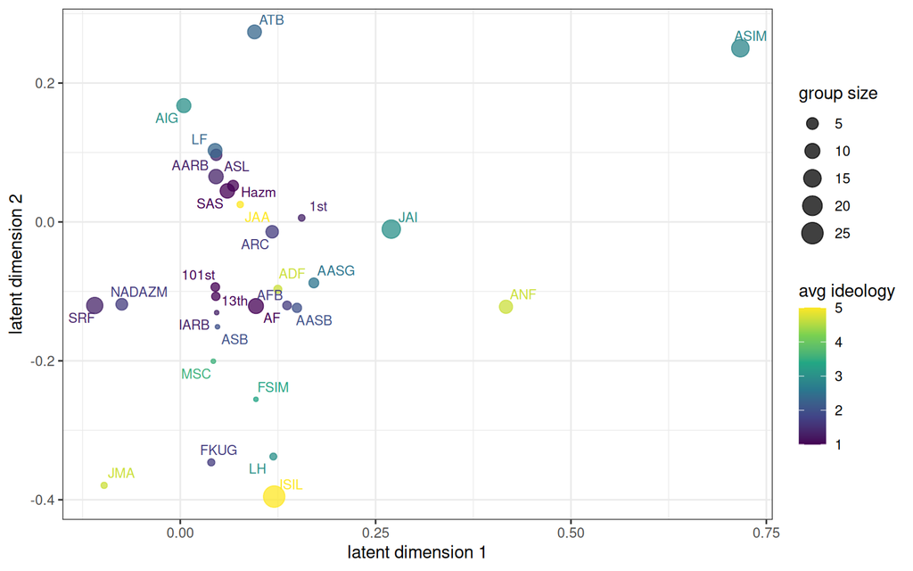

Posterior-mean latent positions from the rank-2 factor model, colored by ideology, sized by group size. Read with Day 3’s Procrustes warning in mind: distances and neighborhoods are meaningful, absolute orientation is not.

```r
udf <- data.frame(u1 = gade_ame$U[, 1], u2 = gade_ame$U[, 2],
                  name = rownames(gade_ame$U),
                  ideol = dl$Xrow[, "averageId_actor1"],
                  size = dl$Xrow[, "size_actor1"])
ggplot(udf, aes(u1, u2, color = ideol, size = size)) +
  geom_point(alpha = 0.75) +
  ggrepel::geom_text_repel(aes(label = name), size = 3,
                           max.overlaps = 12, show.legend = FALSE) +
  scale_color_viridis_c() +
  labs(x = "latent dimension 1", y = "latent dimension 2",
       color = "avg ideology", size = "group size")
```

Two things to read off. First, the eigenvalues come out mixed-sign (133.4, -46.6), and the latent term is not background noise here: it **concentrates**. The single largest entry of the latent surface $ULU'$ belongs to ASIM–ANF: the same two hubs the blockmodel just isolated, at 41 on the probit scale, against a median absolute entry of 1.4. Each axis deserves its honest share of that headline entry. The **positive** axis is the hub gradient itself: dimension 1 correlates 0.91 with degree, ASIM and ANF sit at its extreme, and it contributes 39.8 of the pair’s 41, the negative axis only 1.4 (the split is approximate; $U$ and $\Lambda$ are posterior summaries, not an exact eigendecomposition of the posterior-mean surface, so the two shares sum to 41.3 against the entry’s 40.9). A distance model could imitate *this much*; park the hubs near the center of the space and everyone is close to them.

Second, the **negative** axis, and here is what Hoff (2007) actually proves, because it is a statement about the model *component*, not about any one dataset: a distance term, at any decay, can only ever say *close means likely*; its latent surface is like-attracts-like along every axis, and no arrangement of positions gives it a **negative eigenvalue**. If the fitted surface needs one (ours is -46.6), the distance family is out of vocabulary. So what does ours need it *for*? ISIL, JMA, FKUG, LH sit at the axis’s far end. Be honest about the raw tie rates first, because they alone do not make the case: the quiet four tie to the two hubs at rate 0.62; actually *below* the rest of the periphery’s 0.79, and their zero internal ties (0 across six pairs) is roughly what the periphery’s baseline rate of 0.11 predicts about half the time. On raw rates they look like generic quiet nodes; a latentnet partisan would say so, and would be right. The *latent surface* is where they become distinctive: **after** the covariates and the additive effects have eaten the degree gradient, the surface still averages 4.6 on quiet–hub pairs while averaging -6.1 on quiet–quiet pairs (quiet–periphery sits at -0.2, untouched). Same profile toward the core, actively pushed apart from each other: **stochastic equivalence without cohesion**, with the negative axis’s per-pair contributions of -5.5 down to -7 doing exactly that work, and, since ASIM sits near the axis’s positive extreme, the quiet–ASIM pairs are the clean opposites-attract case (contributions 3.9 to 4.6). The knock-down *proof* that a distance model cannot carry this component is Day 3’s planted disassortative blocks; this is the field specimen, smaller but real. (To be scrupulous toward the rival camp, `latentnet` can bolt actor random effects onto the LDM to handle hubs; see Krivitsky, Handcock, Raftery & Hoff 2009. But the $a_i$ are already *in* this model, the quiet–quiet suppression survives them, and the negative-eigenvalue component itself has no distance representation.) Three lenses in a row, the degree plot, the SBM, and now the factor model, have pointed at the same feature of this network in three vocabularies. (Day 6’s exercise sized this same latent term: sd of the surface $\approx 4.6$ on the probit scale, big, with the same mixed-sign eigenvalues; its caution was that a *nodal* verdict (`averageId`) is model-contingent on a term this large, which is exactly why you read the median entry and the max together: mass concentrated on a few pairs, near-zero almost everywhere else.)

Read the magnitudes with Day-3 discipline, though: there are only 435 binary observations here, and probit-scale entries in the double digits mean the model is stretching a weakly identified latent *scale* to accommodate a few extreme pairs. And note what you *cannot* check: `lame` returns posterior means of $U$ and $\Lambda$, not their draws, so there is no `ess()` to run on the latent scale; `ess(gade_ame)` monitors the regression coefficients only. That is itself the lesson: the latent scale is weakly identified *and* unmonitorable here, so trust the **shape**: who leans toward whom, the sign pattern of the axes; never the raw magnitudes.

```r
round(gof_band(gade_ame$GOF)[, c("sd.rowmean", "trans.dep")], 3)
```

```
#>       sd.rowmean trans.dep
#> 2.5%       0.171    -0.055
#> 97.5%      0.200     0.061
```

The yardstick verdict matches the SRM’s: both statistics covered. So the extra machinery did not change the *structural* verdict: what it changed is one coefficient. Ideological distance’s interval widened past zero once the geometry was allowed to compete for the same structure, and knowing *which of your conclusions survives the richer model* is precisely what the richer model is for.

# 7 Lens 4: The ERGM: Is closure a mechanism?

**What question does it answer?** *“Does a specified local network statistic, such as shared partners or degree popularity, improve the conditional model beyond my covariates? Put a coefficient on it and test it.”* Day 4’s family, and note that this is a genuinely different question from the preceding latent-effects models: they *absorb* structure, while the ERGM *tests* it.

A first specification, the same covariates plus geometrically weighted shared partners, takes about 10 seconds to fit:

```r
snet <- to_statnet(net)
erg_base <- cache_fit("gade_ergm_base",
  ergm(snet ~ edges + edgecov("ideol_diff") + edgecov("powerdiff") +
         edgecov("loc") + edgecov("spons") +
         nodecov("averageId_actor1") + nodecov("size_actor1") +
         gwesp(0.5, fixed = TRUE),
       control = control.ergm(seed = 6886)))
```

```r
eb <- summary(erg_base)$coefficients
round(eb[, c(1, 2, 5)], 3)
```

```
#>                          Estimate Std. Error Pr(>|z|)
#> edges                      -7.202      1.131    0.000
#> edgecov.ideol_diff         -0.252      0.121    0.037
#> edgecov.powerdiff          -0.087      0.029    0.002
#> edgecov.loc                 2.757      1.026    0.007
#> edgecov.spons              -0.378      0.384    0.326
#> nodecov.averageId_actor1    0.177      0.061    0.004
#> nodecov.size_actor1         0.077      0.020    0.000
#> gwesp.fixed.0.5             1.378      0.295    0.000
```

Taken at face value this is a striking result: `gwesp` is 1.38 with p 3e-06; strong evidence, it seems, for a closure mechanism: rebels ally with their allies’ allies. The covariate story agrees with the latent-effects models (ideological distance negative, shared location positive, size positive).

But we built a yardstick precisely so that “taken at face value” is not the last step. Simulate from the fitted ERGM and score it:

```r
sims_base <- simulate(erg_base, nsim = 200, seed = 6886)
gof_ergb <- t(sapply(sims_base, function(s) {
  m <- as.matrix(s); diag(m) <- NA; calc_gof(m)
}))
rbind(observed = round(gof_obs, 3),
      round(apply(gof_ergb, 2, quantile, c(0.025, 0.975)), 3))
```

```
#>          actor_sd cycle trans
#> observed    0.184 0.007 0.007
#> 2.5%        0.117 0.058 0.058
#> 97.5%       0.158 0.144 0.144
```

Two misses, in opposite directions. The simulated networks *overshoot* transitivity (band [0.058, 0.144] against an observed 0.007) and *undershoot* actor heterogeneity (band [0.117, 0.158] against 0.184). The diagnosis writes itself: this specification has **no term for per-actor activity**, so the only place the fitter could put the hub structure was the shared-partner term because hubs manufacture shared partners mechanically. The big `gwesp` is real *as a description of the sufficient statistics*, but it is doing the job of the missing sociality term, not measuring a closure mechanism.

The honest move is the ERGM-day move: **respecify**. Give the model a degree term and see what happens to closure once degree has a voice. This version takes about 30 seconds from a cold start and is cached:

```r
erg_deg <- cache_fit("gade_ergm_deg",
  ergm(snet ~ edges + edgecov("ideol_diff") + edgecov("powerdiff") +
         edgecov("loc") + edgecov("spons") +
         nodecov("averageId_actor1") + nodecov("size_actor1") +
         gwdegree(0.5, fixed = TRUE) + gwesp(0.5, fixed = TRUE),
       control = control.ergm(seed = 6886)))
```

```r
ed <- summary(erg_deg)$coefficients
round(ed[, c(1, 2, 5)], 3)
```

```
#>                          Estimate Std. Error Pr(>|z|)
#> edges                      -9.232      1.330    0.000
#> edgecov.ideol_diff         -0.228      0.111    0.039
#> edgecov.powerdiff          -0.097      0.030    0.001
#> edgecov.loc                 2.801      1.028    0.006
#> edgecov.spons              -0.305      0.393    0.437
#> nodecov.averageId_actor1    0.175      0.065    0.007
#> nodecov.size_actor1         0.083      0.022    0.000
#> gwdeg.fixed.0.5             2.501      0.886    0.005
#> gwesp.fixed.0.5             2.260      0.461    0.000
```

```r
c(AIC_base = round(AIC(erg_base), 1), AIC_deg = round(AIC(erg_deg), 1))
```

```
#> AIC_base  AIC_deg
#>    331.2    324.1
```

```r
sims_deg <- simulate(erg_deg, nsim = 200, seed = 6886)
gof_ergd <- t(sapply(sims_deg, function(s) {
  m <- as.matrix(s); diag(m) <- NA; calc_gof(m)
}))
round(apply(gof_ergd, 2, quantile, c(0.025, 0.975)), 3)
```

```
#>       actor_sd cycle trans
#> 2.5%     0.108 0.037 0.037
#> 97.5%    0.158 0.139 0.139
```

AIC improves by 7.1 points, so the degree term earns its keep, and yet the yardstick misses persist. And notice what `gwesp` did: it did not shrink, it *grew*, from 1.38 to 2.26. That is not closure getting stronger. One fixed-decay `gwdegree` parameter is not an $a_i$; it cannot reproduce a *smooth per-actor gradient*, so the two terms are now jointly improvising a compensation for the still-missing actor heterogeneity, and neither coefficient is readable as its named mechanism. The GOF miss, not the coefficient, is the verdict.

So take the family’s honest move to its logical end: give **every actor its own edge parameter**: `sociality()`, the ERGM’s version of the SRM’s $a_i$. The nodal covariates have to come out (per-actor parameters absorb every nodal main effect; leave them in and `ergm` will rightly complain the model is nonidentifiable), and closure finally competes against a full activity gradient. This fit takes about five seconds from a cold start and is cached:

```r
erg_soc <- cache_fit("gade_ergm_soc",
  ergm(snet ~ edges + edgecov("ideol_diff") + edgecov("powerdiff") +
         edgecov("loc") + edgecov("spons") +
         sociality(nodes = -1) + gwesp(0.5, fixed = TRUE),
       control = control.ergm(seed = 6886)))
```

```r
es <- summary(erg_soc)$coefficients
round(es["gwesp.fixed.0.5", c(1, 2, 5)], 3)
```

```
#>   Estimate Std. Error   Pr(>|z|)
#>      0.184      0.465      0.692
```

```r
sims_soc <- simulate(erg_soc, nsim = 200, seed = 6886)
gof_ergs <- t(sapply(sims_soc, function(s) {
  m <- as.matrix(s); diag(m) <- NA; calc_gof(m)
}))
rbind(observed = round(gof_obs, 3),
      round(apply(gof_ergs, 2, quantile, c(0.025, 0.975)), 3))
```

```
#>          actor_sd  cycle  trans
#> observed    0.184  0.007  0.007
#> 2.5%        0.172 -0.075 -0.075
#> 97.5%       0.207  0.061  0.061
```

`gwesp` collapses to 0.18 (p = 0.69), and *both* yardstick statistics are now covered. Two reading notes before the verdict. The collapse is a verdict of *nothing left that needs a closure term*, not a proof of absence: after 29 sociality parameters the interval is wide ([-0.73, 1.1]), so the coefficient and GOF coverage together say that this specification does not detect a remaining shared-partner pattern. Neither one proves that closure is absent or identifies a causal tie-formation mechanism. (And the point estimate 0.184 matching the observed `actor_sd` of 0.184 to three digits is pure coincidence: a log-odds coefficient and a row-mean sd live on different scales entirely.) With that said: given its own $a_i$ analogue, the ERGM **agrees with the latent-effects models**: no detectable residual closure mechanism in this network. The two families only looked like rivals while the ERGM was missing a term. The price is the trade the families always make: 29 sociality parameters on 30 nodes (fine here, hopeless at $n = 3000$: the scale section’s lesson arriving early), and the nodal covariates are gone, so if your *question* was a coefficient on group size, this specification stopped answering it. The ERGM buys you a **testable coefficient on structure** at the price of writing every form of heterogeneity into the sufficient statistics by hand; the latent-effects models absorb heterogeneity natively at the price of never giving you a p-value on “closure is a mechanism here.”

**CautionThis is not “ERGMs lose”: Read before quoting**

Three honesty notes, because I have a horse in this race and the ERGM day was built with full respect. **First**, the fitted ERGM reproduces its own sufficient statistics beautifully; simulate from `erg_base` and the observed edge count, gwesp, and triangle count all land mid-band. It is failing *our* yardstick, which contains a statistic (`sd` of row means) that the first two specifications do not include. A model matches what you ask it to match; that is the deepest lesson of the exponential family. **Second**, the fix came from *inside* the family; you just watched `sociality()` do it, and curved alternatives with estimated decay would refine it further; the point of the three-step arc is the *contrast of philosophies*, not an exhaustive search. **Third**, on a network where a closure statistic remains informative beyond degree; Day 4’s friendship data, say: the ERGM is the only tool in this course that can put a directly testable parameter on that specified structure. The parameter still does not distinguish closure from an omitted process that generates the same statistic. Keep it in the kit.

# 8 The payoff table: one network, every lens

First, the yardstick scoreboard. The GLM’s simulations are already in hand from lens 0 (`gof_glm`, the day’s first NO); the one missing simulation is the blockmodel, scored from its fitted block-tie rates:

```r
set.seed(6886)
Pi <- bm$model_parameters[[K_star]]$pi
Pb <- Pi[Z, Z]                            # Each pair's block-implied rate
gof_blk <- t(replicate(200, {
  S <- matrix(0, 30, 30)
  S[upper.tri(S)] <- rbinom(choose(30, 2), 1, Pb[upper.tri(Pb)])
  S <- S + t(S); diag(S) <- NA; calc_gof(S)
}))
```

```r
band_txt <- function(x, d = 3) {
  q <- quantile(x, c(0.025, 0.975))
  paste0("[", round(q[1], d), ", ", round(q[2], d), "]")
}
covered <- function(x, obs) {
  q <- quantile(x, c(0.025, 0.975))
  ifelse(obs >= q[1] & obs <= q[2], "yes", "NO")
}
score <- data.frame(
  model = c("glm (independence)", "srm (additive effects)",
            "sbm (discrete blocks)", "ame (add. + geometry)",
            "ergm (gwesp)", "ergm (gwdeg + gwesp)",
            "ergm (sociality + gwesp)"),
  actor_sd = c(band_txt(gof_glm[, "actor_sd"]),
               band_txt(gade_srm$GOF[-1, "sd.rowmean"]),
               band_txt(gof_blk[, "actor_sd"]),
               band_txt(gade_ame$GOF[-1, "sd.rowmean"]),
               band_txt(gof_ergb[, "actor_sd"]),
               band_txt(gof_ergd[, "actor_sd"]),
               band_txt(gof_ergs[, "actor_sd"])),
  hit_a = c(covered(gof_glm[, "actor_sd"], gof_obs["actor_sd"]),
            covered(gade_srm$GOF[-1, "sd.rowmean"], gof_obs["actor_sd"]),
            covered(gof_blk[, "actor_sd"], gof_obs["actor_sd"]),
            covered(gade_ame$GOF[-1, "sd.rowmean"], gof_obs["actor_sd"]),
            covered(gof_ergb[, "actor_sd"], gof_obs["actor_sd"]),
            covered(gof_ergd[, "actor_sd"], gof_obs["actor_sd"]),
            covered(gof_ergs[, "actor_sd"], gof_obs["actor_sd"])),
  trans = c(band_txt(gof_glm[, "trans"]),
            band_txt(gade_srm$GOF[-1, "trans.dep"]),
            band_txt(gof_blk[, "trans"]),
            band_txt(gade_ame$GOF[-1, "trans.dep"]),
            band_txt(gof_ergb[, "trans"]),
            band_txt(gof_ergd[, "trans"]),
            band_txt(gof_ergs[, "trans"])),
  hit_t = c(covered(gof_glm[, "trans"], gof_obs["trans"]),
            covered(gade_srm$GOF[-1, "trans.dep"], gof_obs["trans"]),
            covered(gof_blk[, "trans"], gof_obs["trans"]),
            covered(gade_ame$GOF[-1, "trans.dep"], gof_obs["trans"]),
            covered(gof_ergb[, "trans"], gof_obs["trans"]),
            covered(gof_ergd[, "trans"], gof_obs["trans"]),
            covered(gof_ergs[, "trans"], gof_obs["trans"])))
score
```

| model | actor_sd | hit_a | trans | hit_t |
| --- | --- | --- | --- | --- |
| glm (independence) | [0.073, 0.119] | NO | [-0.038, 0.03] | yes |
| srm (additive effects) | [0.145, 0.207] | yes | [-0.099, 0.067] | yes |
| sbm (discrete blocks) | [0.14, 0.186] | yes | [-0.107, -0.016] | NO |
| ame (add. + geometry) | [0.171, 0.2] | yes | [-0.055, 0.061] | yes |
| ergm (gwesp) | [0.117, 0.158] | NO | [0.058, 0.144] | NO |
| ergm (gwdeg + gwesp) | [0.108, 0.158] | NO | [0.037, 0.139] | NO |
| ergm (sociality + gwesp) | [0.172, 0.207] | yes | [-0.075, 0.061] | yes |

```r
checkpoint(obs_actor_sd = round(gof_obs["actor_sd"], 3),
           obs_trans = round(gof_obs["trans"], 4),
           models_covering_both = sum(score$hit_a == "yes" &
                                      score$hit_t == "yes"))
```

```
#> ------------------------------------------------------------------
#> CHECKPOINT: obs_actor_sd = 0.184   |   obs_trans = 0.007   |   models_covering_both = 3
#> ------------------------------------------------------------------
```

Read the scoreboard carefully before quoting it, because two rows are traps for the fast reader. The **GLM covers `trans`**: not because independence captures triangle structure, but because this network has no excess transitivity for independence to miss; a covered band is evidence a statistic was *reproducible*, never that the model is right. And the **SBM squeaks past `actor_sd`** (observed 0.184 sits at the very edge of its band): two boxes can mimic hubs-versus-everyone at the coarsest level, even while the same simulations come out *anti*-transitive and miss the other statistic. GOF by simulation is a falsification tool; it can tell you a model failed, and it can fail to fail; it never certifies.

One comparability caveat, so nobody accuses the scoreboard of a home-team call: the SRM and AME rows are posterior-predictive bands (parameter uncertainty included), while the GLM, SBM, and ERGM rows simulate at frozen point estimates: the Bayesian bands are somewhat wider by construction. The ERGM base and gwdegree misses survive the caveat comfortably (they miss by direction, not by a hair), but the SBM’s edge-of-band coverage should be read with it in mind. And note the symmetry the row count hides: the ERGM family gets three rows only because we watched it repair itself, and the GLM row *is* the latent-effects family stripped of its heterogeneity device; it fails `actor_sd` exactly as the first two ERGM rows do. Each family fails when denied its own $a_i$, and each passes when granted it; the three ERGM rows are the GLM-to-SRM jump taken in steps.

The scoreboard aligned the *fit* verdicts; the second half of the payoff aligns the **coefficients**, and this piece is built to leave the room with you. Every family in this course prints its coefficient table in its own dialect: `summary()` matrices for the GLM and the ERGM, posterior `BETA` draws for `lame`, a robust-variance vector for DCR. `_compare_helpers.R`, which ships in this day’s folder next to the qmd, has one `row_*()` function per dialect, and each returns the *same* five-column frame, model, term, estimate, lo, hi, so the whole morning rbinds into one picture:

```r
source("_compare_helpers.R")   # row_glm, row_dcr, row_ame, row_ergm, row_saom, forest_plot
rows <- rbind(row_glm(glm_fit),
              row_dcr(glm_fit, dcr_out),
              row_ame(gade_srm, "srm (additive)"),
              row_ame(gade_ame, "ame (R = 2)"),
              row_ergm(erg_base, "ergm (gwesp)"))
head(rows, 3)
```

| model | term | estimate | lo | hi |
| --- | --- | --- | --- | --- |
| glm (naive) | (baseline) | -4.9966437 | -6.4334356 | -3.5598517 |
| glm (naive) | ideol_diff | -0.1143738 | -0.2830194 | 0.0542717 |
| glm (naive) | powerdiff | -0.0161153 | -0.0538991 | 0.0216686 |

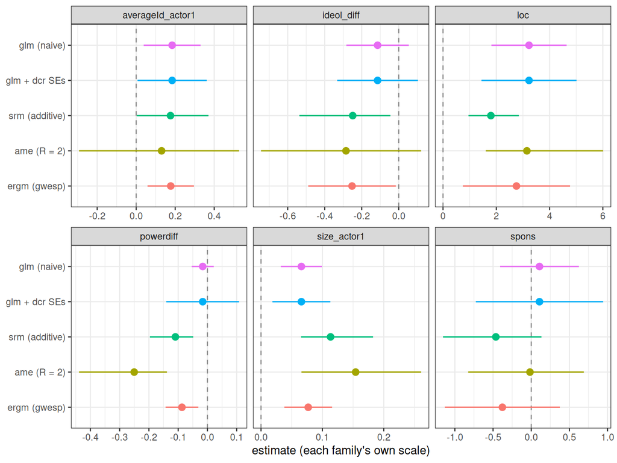

Five families, one forest. Each facet is a covariate, each row a model, each segment a 95% interval on that family’s own scale. Read sign and interval-vs-zero across rows; never read size across families.

```r
forest_plot(rows)
```

**The one rule of use, out loud:** this is a specification-sensitivity display, not a method-performance comparison. First verify that rows, covariate construction, and the target contrast are genuinely aligned. These helpers align interval summaries, not magnitudes. The GLM and ERGM rows live on the logit scale, the lame rows on the probit scale (roughly 1.6x smaller for the same effect), and the ERGM’s coefficients are conditional on the rest of the graph. Therefore, a shorter segment is not a smaller effect. Even “same sign?” and “does the interval clear zero?” are useful only when the underlying estimand is comparable. Read this one that way and the morning compresses into one picture: shared location is positive in every row of its facet; ideological distance is negative everywhere but clears zero only in the SRM and ERGM rows: the two specifications that gave the hub structure its own term, and not in the AME row, which is the wobble from Section 6, now visible as geometry; and the DCR row is the naive GLM row with wider whiskers, Day 6 in one facet. (The baseline and `gwesp` terms are dropped automatically; they have no cross-family analogue.)

And the take-home part: each `row_*()` needs only the fitted object (plus, for `row_dcr`, the DCR output); point them at *your* fits and `forest_plot()` works unchanged. The file also has a `row_saom()` for your HW 4 `sienaFit` objects, with a loud comment you should take seriously: SAOM rate and evaluation parameters answer “how do ties change?”, not “which ties exist?”, so they get their own plot, never a facet beside the tie models.

Now the table that matters more than the scoreboard: **what question each lens asked, and what it answered here**:

| Lens | Its question | Its answer on this network |
| --- | --- | --- |
| Descriptives | Who is central, who clusters? | Two dominant hubs, ideological bunching, low density |
| GLM + DCR SEs | Which pair traits go with ties, with honest inference? | Location and size most robustly (ideology’s nodal term just survives); naive SEs too confident, 3.3x at worst on the genuinely clustered term |
| SRM | How much is actor-level gregariousness? | A lot: a first-class actor variance; homophily *sharpens* once actors get intercepts |
| SBM | Do actors come in discrete kinds? | Mostly no; a thin two-hub core vs. everyone else; the smooth gradient defeats the boxes |
| AME | Is there residual third-order geometry? | Yes, but concentrated: the geometry re-finds the SBM’s hub core, mixed-sign axes; ideology’s verdict softens once geometry competes |
| ERGM | Is a shared-partner term still informative beyond covariates and actor activity? | Not detected in the sociality specification; gwesp becomes imprecise and both yardstick statistics are covered, which is compatibility rather than proof of no closure |
| (SAOM / TERGM) | How do ties change over waves? | Not askable; this is a single snapshot; the wave models of Days 4–5 need panels |

Seven lenses produce several apparent tensions, and most become understandable once each answer is attached to *its own question* and specification. The apparent contradiction (“the ERGM found closure! The SRM says it is all gregariousness!”) Weakens when actor activity is represented in both models. That is a substantive reconciliation, not a guarantee that different defensible specifications will always agree. Where the answers genuinely converge (four lenses independently pointing at the same two hubs), that convergence is the strongest empirical claim the day produces. That is the discipline the decision framework is about to make mechanical.

**ImportantThe payoff table in one line**

The models did not disagree about the network; they answered different questions about it, and every apparent fight between network models you will see in a seminar should first be checked for exactly this.

# 9 The decision framework

Here is the artifact to screenshot. Start from your **question**, not your data format, and walk down:

```
flowchart LR
  Q["what is your question?"]
  Q --> D["describe /<br/>visualize"]
  Q --> M["measure a latent<br/>quantity"]
  Q --> B["honest coefficient<br/>on a covariate"]
  Q --> S["is local structure<br/>a mechanism?"]
  Q --> T["how do ties<br/>change?"]
  Q --> C["causal effect<br/>of a treatment"]

  D --> D1["centrality, communities,<br/>netify summaries: Week 0 / Day 1"]

  M --> M1{"kinds or<br/>gradients?"}
  M1 -->|"discrete roles"| M2["blockmodel positions:<br/>Day 2"]
  M1 -->|"continuous map"| M3["AME latent positions,<br/>additive effects: Day 3"]

  B --> B1{"model the dependence<br/>or just fix the SEs?"}
  B1 -->|"absorb it"| B2{"binary or valued?<br/>one net or panel?"}
  B2 --> B3["SRM / AME family:<br/>Days 2 and 3; lame handles<br/>valued + longitudinal"]
  B1 -->|"inference only"| B4["dyadic cluster-robust SEs:<br/>Day 6"]

  S --> S1["ERGM + GOF:<br/>Day 4"]

  T --> T1{"panel waves or<br/>timestamped events?"}
  T1 -->|"waves"| T2["SAOM: Day 5;<br/>TERGM: Day 4"]
  T1 -->|"timestamps"| T3["relational event models:<br/>Today, Section 10"]

  C --> C1{"can you defend<br/>interference + exposure<br/>assumptions?"}
  C1 -->|"yes (design)"| C2["design-based estimators:<br/>Day 6 literacy list"]
  C1 -->|"not really"| C3["honest observational claim:<br/>association + DCR SEs +<br/>sensitivity: Day 6"]
```

And the same framework as a table, with the follow-up questions that pick the variant:

| Your question | First tool | The follow-up questions that matter |
| --- | --- | --- |
| Describe / visualize | Centrality, community detection, `netify` summaries | One network or many? Weighted?; Purely a description, no uncertainty |
| Measure a latent quantity (positions, roles, affinities) | Blockmodel (kinds) or AME (gradients) | Discrete or continuous? Directed? Do you need uncertainty on the positions? (Procrustes, Day 3) |
| Honest $\beta$ with dependence as nuisance | SRM/AME | Binary, ordinal, count? (`family=` in `lame`) · one snapshot or panel? (`lame` is longitudinal) · worried the latent terms eat your covariate? Then also run DCR and compare *verdicts* (Day 6) |
| Honest inference only, no structural model | Dyadic cluster-robust SEs (`dcr`) | Is your estimand really just the conditional association? |
| Structure as a testable mechanism | ERGM | Which local configurations encode your theory? Does GOF survive? Valued ties -> valued ERGM (ancillary) |
| Tie dynamics | SAOM or TERGM (waves) / REM (timestamps) | Waves: actor-oriented (SAOM, Day 5) or tie-oriented (TERGM, taught Day 4)? Co-evolution of behavior? Composition change? (Ancillary) · events: ordinal vs interval timing |
| How a shock to one dyad propagates over time | DBN (dynamic bilinear); Section 11 | Propagation or positions? (The DBN-vs-lame question) · is the panel long enough to pin the lag operators? |
| Which observable features make actors influential, and on whom | SIR (influence regression); Section 12 | Directed longitudinal counts? Can you name the observed features ($W_r$) that could carry the influence? |
| Causal effect | Day 6’s ladder | Randomized? Then exposure mappings and design. Observational? Say “we cannot defend the assumptions” when you cannot; and mean it |

One gate *before* any branch: if your data has two **kinds** of nodes, such as students $\times$ classrooms, groups $\times$ events, states $\times$ treaties; stay two-mode and read Section 13 before picking a tool. Projecting to one mode first manufactures the very triangle structure every branch of this flowchart will then dutifully “find.”

Three walkthroughs, one from each corner of the room. I narrate the first two; the third is yours; before I walk it, remote folks type the branch you think it lands on in the chat, in-room tell your neighbor, and then everyone does the same move once more on their *own* dataset (one sentence: branch + runner-up). That last round *is* exercise 1 of Section 17, done live; if you post your sentence now, “your turn” starts at exercise 2 for you.

**The education researcher.** Three waves of friendship nominations in two classrooms, plus each student’s reading score; the question is whether kids befriend similar-scoring peers or converge after befriending. *Walk:* the question is dynamic, selection versus influence, with panel waves, so the framework lands on the SAOM, and specifically on Day 5’s co-evolution machinery. An ERGM per wave would conflate the two mechanisms by construction; that was the entire argument of Day 5.

**The public-health researcher.** One snapshot of patient-transfer counts among 120 hospitals, and the question is whether shared ownership predicts flows, controlling for capacity. *Walk:* honest-$\beta$ with dependence as nuisance; valued (counts, so `family = "poisson"`ish in `lame`); directed. An SRM/AME with a count family, plus a DCR pass on the naive model to see whether the *verdict* survives both routes.

**The political economist.** Twenty years of sanctions and trade, and the draft’s abstract says “the effect of sanctions on trade.” *Walk:* the word *effect* sends you down the causal branch. The first gate asks whether you can defend interference and exposure assumptions in observational dyadic panels, and nobody has credibly passed it in this literature. The honest landing spot is Day 6’s: model the association with the dependence handled (AME and/or DCR), run the sensitivity analysis, and write “associated with,” not “caused.”

**WarningThe framework’s one rule**

If you cannot say which branch you are on; description, measurement, honest-$\beta$, mechanism, dynamics, causal; you are not ready to fit anything. The most expensive mistakes in this literature are not wrong models; they are right models pointed at the wrong question.

# 10 The frontier: Relational event models, live

> One more thing before the tour: none of this requires a new toolchain. The Netify object you built on Day 1 already speaks every dialect on this map, `to_lame()`, `to_dbn()`, `to_statnet()`, `to_igraph()`, `to_amen()`, and `sir` takes the same plain arrays those produce. The object is the entry ticket; the frontier is just more doors.

Everything this course modeled was a **snapshot** (or a panel of them): the network held still long enough to be measured. But a growing share of network data does not arrive as snapshots; it arrives as **timestamped events**. Emails, phone calls, radio communications, interstate incidents, retweets: “I happened at 14:32,” one row per event. Day 5’s SAOM treats the process between waves as unobserved and *infers* the micro-steps; when you observe the event stream directly there is nothing to infer; you can model the sequence itself. That is the **relational event model** (Butts 2008): a hazard for *which dyad fires next*, given the full history so far. (A *hazard* is just a rate, of all the pairs that could produce the next event, how strongly does the history so far tilt the odds toward this particular one. That is the whole survival-analysis vocabulary you need today.)

For political science, the natural examples are timestamped diplomatic exchanges, protest and repression events, legislative speeches and responses, battlefield interactions, or public messages among political organizations. The substantive question is not merely whether two actors ever interacted. It is how the evolving history changes who acts toward whom next.

For the ordinal REM fitted below, estimation proceeds as follows:

1. Put the observed events in time order and define the dyads eligible to produce each next event.
2. Immediately before event $m$, calculate the history statistics for every eligible dyad, such as recency, repetition, popularity, or turn-taking.
3. Use the observed event’s sender-receiver pair as the chosen alternative and all other eligible dyads as the comparison set.
4. Convert each dyad’s linear predictor into a probability of being the next event through a multinomial-logit risk-set denominator.
5. Multiply those event-by-event probabilities, or equivalently sum their log values, to form the ordinal likelihood.
6. Optimize the coefficients, then use the Hessian to estimate their covariance matrix.
7. Check whether the fitted history effects reproduce event ordering and whether a clock-time model is needed when waiting times are substantively meaningful.

The model is therefore learning from a sequence of choices among risk sets. Aggregating the stream into a static network removes exactly the comparisons used by the estimator.

The demo data is a neutral one; phone calls among students in an MIT dormitory, shipped with the `goldfish` package. The unit is not “a tie exists”; it is “a call happened”:

```r
data("Social_Evolution", package = "goldfish")
head(calls, 3)
```

| time | sender | receiver | increment |
| --- | --- | --- | --- |
| 1220733470 | Actor 72 | Actor 50 | 1 |
| 1221102974 | Actor 43 | Actor 51 | 1 |
| 1221784293 | Actor 43 | Actor 51 | 1 |

```r
c(events = nrow(calls), students = nrow(actors),
  days = round(diff(range(calls$time)) / 86400))
```

```
#>   events students     days
#>      439       84       42
```

439 calls among 84 students over 42 days; about 6 weeks in the fall of 2008; the calls slice of the eight-month “social evolution” study. `relevent::rem.dyad()` wants integer actor ids and a time-ordered edgelist:

```r
ids <- setNames(seq_len(nrow(actors)), actors$label)
el <- cbind(time = calls$time - min(calls$time) + 1,
            snd = ids[calls$sender], rec = ids[calls$receiver])
el <- el[order(el[, 1]), ]
```

The model: which pair fires next, as a function of the history. We give it four history statistics; recency of $j\to i$ (have you called me lately?), recency of $i\to j$ (do I habitually call you?), the receiver’s accumulated degree (popularity), and the classic *participation shift* ab–ba (I just called you; do you call me straight back?). The fit takes about 25 seconds from a cold start and is cached afterward:

```r
rem_calls <- cache_fit("rem_calls", {
  invisible(capture.output(
    f <- relevent::rem.dyad(el, n = nrow(actors),
      effects = c("RRecSnd", "RSndSnd", "NTDegRec", "PSAB-BA"),
      ordinal = TRUE, hessian = TRUE)))
  f
})
summary(rem_calls)
```

```
#> Relational Event Model (Ordinal Likelihood)
#>
#>          Estimate Std.Err Z value Pr(>|z|)
#> NTDegRec  7.25357 0.64195 11.2993   <2e-16 ***
#> RRecSnd   0.12253 0.16318  0.7509   0.4527
#> RSndSnd   6.24911 0.14072 44.4091   <2e-16 ***
#> PSAB-BA   3.58481 0.17631 20.3323   <2e-16 ***
#> ---
#> Signif. codes:  0 '***' 0.001 '**' 0.01 '*' 0.05 '.' 0.1 ' ' 1
#> Null deviance: 7769.999 on 439 degrees of freedom
#> Residual deviance: 3525.881 on 435 degrees of freedom
#>  Chi-square: 4244.118 on 4 degrees of freedom, asymptotic p-value 0
#> AIC: 3533.881 AICC: 3533.973 BIC: 3550.219
```

**The lag trick that finds instant call-backs: Four lines of base R**

```r
co <- rem_calls$coef
se <- setNames(sqrt(diag(rem_calls$cov)), names(co))
cl  <- calls[order(calls$time), ]
imm <- which(cl$sender[-1] == cl$receiver[-nrow(cl)] &
             cl$receiver[-1] == cl$sender[-nrow(cl)]) + 1
gap_med <- median(cl$time[imm] - cl$time[imm - 1])
```

Read it like a hazard model, because it is one, with one reading rule: do not rank these raw coefficients against each other, because each history statistic lives on its own scale (`NTDegRec`, for instance, multiplies a 0–1 degree share, so its coefficient is not comparable to a p-shift indicator’s). The strong effects are **inertia**: `RSndSnd` at 6.25: whoever you have called most recently, you keep calling, and **turn-taking**: the ab–ba p-shift at 3.58 means that immediately after a call, the return call is $e^{3.58} \approx 36$ times more likely than baseline to be the very next event. Receiver popularity (`NTDegRec`, 7.25) matters too. And note the honest null: generic reciprocity-as-recency (`RRecSnd`) is only 0.12 with a standard error of 0.16, in *this* stream, reciprocity is not a slow-burning disposition, it is an immediate call-back: 153 of the 439 calls are instant returns of the event directly before them, with a median gap of 20 seconds. **No snapshot model can even express that sentence.** Collapse these 439 events into a week-by-week panel for a SAOM, six waves, and the ab–ba dynamic, the single strongest regularity in the data, averages away into a generic reciprocity effect.

`ordinal = TRUE` means we modeled the *sequence* (which dyad fires next), ignoring the waiting times; that is the robust default when timestamps have gaps or heaping. With `ordinal = FALSE` you model the clock too.

**When do you reach for a REM over the wave models; Day 5’s SAOM, or the TERGM you fit on Day 4?** Ask one question: *are the waves real?* If the process genuinely moves in survey waves (friendship nominations each semester), the wave models are the honest choice, and Days 4–5 already gave you the tie-oriented-versus-actor-oriented follow-up. If the “waves” are just your aggregation of a timestamped stream, you are throwing away the sequence, the REM’s entire subject, and the wave machinery spends effort inferring what you already observed.

**NoteThe same stream in `goldfish`, and the actor-oriented cousin**

`goldfish` (Stadtfeld & Block 2017) fits the same family with a different accent. Its REM on this stream, with inertia, reciprocity, and closure statistics, tells a compatible story; inertia dominates, closure is null. The fit takes about 30 seconds from a cold start and is cached:

```r
gf_rem <- cache_fit("gf_rem", {
  callNetwork <- defineNetwork(nodes = actors, directed = TRUE)
  callNetwork <- linkEvents(x = callNetwork, changeEvent = calls,
                            nodes = actors)
  callsDep <- defineDependentEvents(events = calls, nodes = actors,
                                    defaultNetwork = callNetwork)
  invisible(capture.output(
    m <- estimate(callsDep ~ inertia + recip + trans, model = "REM")))
  m
})
data.frame(effect = rownames(gf_rem$names),
           est = round(gf_rem$parameters, 2),
           se  = round(gf_rem$standardErrors, 2))
```

| effect | est | se |
| --- | --- | --- |
| inertia | 6.20 | 0.15 |
| recip | 1.43 | 0.12 |
| trans | 0.22 | 0.16 |

One visible difference, and it is a live specimen of the day’s whole lesson: `recip` here is strongly positive (1.43, se 0.12) where `relevent`’s `RRecSnd` was null. No contradiction; goldfish’s `recip` is a *cumulative count* and this specification has no ab–ba participation-shift term competing for the signal, so the 153 instant call-backs have nowhere to load except generic reciprocity. Same stream, same behavior; **the statistic you include decides which effect gets the credit**: the omitted-term lesson of the ERGM section, replayed in continuous time.

Goldfish’s real specialty is the **DyNAM** (`model = "DyNAM"`): an *actor-oriented* event model, where the sender first decides to act and then chooses a receiver: the same tie-oriented-versus-actor-oriented axis you met as TERGM-versus-SAOM, replayed in continuous time. If your theory is about actors making choices (who does a legislator co-sponsor next?), the DyNAM’s decomposition is the natural fit; if it is about dyadic hazards (which pair fights next?), the REM is.

# 11 The frontier: The tensor lane: When the network is a stack, not a slice

Everything this week handled one adjacency matrix at a time, even the longitudinal days treated time as a sequence of slices. But your data was never really a matrix. A directed network observed over time is a three-way array (sender x receiver x time); add relation types and it is four-way. The tensor literature takes that shape seriously: instead of vectorizing everything into dyad-rows, it puts structure on each mode of the array with bilinear forms like $A X B^\top$, one operator for the sender mode, one for the receiver mode, a kronecker product instead of a giant unstructured coefficient block. The lineage to know is Hoff (2015), which built multilinear tensor regression for exactly our kind of longitudinal relational data, and Chen, Xiao & Yang (2021), who developed the matrix autoregression on the time-series side. Same object, two literatures.

The runnable instance is `dbn` (Salau & Minhas, on GitHub under Netify-dev). It moves the bilinear form into the lag slot of a state-space model:

$$\Theta_t = M + A_t\,(\Theta_{t-1} - M)\,B_t^\top + \varepsilon_t,
\qquad Y_t = \Theta_t + \eta_t .$$

Read it the way you read the map on Day 1: $\Theta_t$ is the de-noised network, $M$ is the long-run baseline (the stable rivalries and enduring friendships), and the **lag operators** $A_t$ (sender side) and $B_t$ (receiver side) together define the propagation operator. In an asymmetric model, an entry of $A_t$ does not by itself equal a percentage transmitted because the same prediction also depends on $B_t$ and the scale can move between the two matrices. The invariant object is the map $X \mapsto A_t X B_t^\top$, which impulse responses summarize below. That is a different kind of quantity from anything we estimated this week: not a position and not a covariate effect, but a model-based propagation channel.

This fit takes about one second. Yes, really; bilinear structure is cheap at classroom scale.

```r
library(dbn)   # remotes::install_github("netify-dev/dbn")

sim <- simulate_dynamic_dbn(n = 8, time = 10, seed = 6886)
fit_dbn <- cache_fit("fit_dbn_frontier", {
  set.seed(6886)
  dbn(sim$Z, model = "dynamic", family = "gaussian",
      nscan = 800, burn = 400, odens = 4, verbose = FALSE)
})
```

One workflow note before reading the fit, because the package builds it in: the same model has a **fast deterministic engine**, `dbn_als()`, which uses alternating least squares to produce a point estimate in a blink, with no draws:

```r
als <- dbn_als(sim$Z, family = "gaussian", verbose = FALSE, seed = 6886)
r_als <- cor(c(als$Theta[, , , , 1]),        # ALS de-noised surface...
             c(apply(fit_dbn$Theta, 1:4, mean)))  # ...vs. the MCMC's
data.frame(converged = als$converged, iterations = als$n_iter,
           r_vs_mcmc = round(r_als, 2))
```

| converged | iterations | r_vs_mcmc |
| --- | --- | --- |
| TRUE | 26 | 0.58 |

The working rule is **explore with ALS, publish with MCMC**: iterate on your specification against the instant engine, then pay for the draws once. And note the two engines’ de-noised surfaces correlate at only 0.58 here; that is not a bug, it is the identification aside below arriving early: on a deliberately tiny panel (10 periods of 8 actors) the per-transition operators are weakly pinned, so the MCMC’s pooling prior does real work that a bare point estimate cannot, which is exactly why the published table comes from the draws.

```r
# Posterior-mean sender-side factor at t = 5, under the package's fitted
# scale convention. Interpret it jointly with B, not as a standalone share.
A_t5 <- apply(simplify2array(lapply(fit_dbn$A, function(a) a[, , 5])),
              1:2, mean)
round(A_t5[1:4, 1:4], 2)
```

```
#>       [,1]  [,2]  [,3]  [,4]
#> [1,]  0.59  0.10  0.05 -0.06
#> [2,] -0.01  0.61  0.01 -0.05
#> [3,]  0.10  0.02  0.65 -0.02
#> [4,]  0.08 -0.09 -0.04  0.66
```

Under this fitted convention the diagonal sits near 0.59 and the off-diagonals are no larger than 0.11. Those entries describe the sender-side factorization, not invariant transmission shares. For substantive propagation, use the joint operator or the impulse response next. Because the model has a transition operator, it supports outputs that no same-period model can even define. Shock one dyad and watch it ripple:

```r
set.seed(6886)
shock <- build_shock(m = 8, type = "unit_edge", i = 1, j = 2)
irf <- compute_irf(fit_dbn, shock = shock, H = 3, n_draws = 100,
                   stat_fun = dbn::stat_density)
irf
```

| horizon | mean | median | sd | q025 | q975 | q10 | q90 |
| --- | --- | --- | --- | --- | --- | --- | --- |
| 0 | 0.0178571 | 0.0178571 | 0.0000000 | 0.0178571 | 0.0178571 | 0.0178571 | 0.0178571 |
| 1 | 0.0159782 | 0.0143716 | 0.0075241 | 0.0040045 | 0.0310813 | 0.0077366 | 0.0274862 |
| 2 | 0.0121231 | 0.0111453 | 0.0115095 | -0.0054341 | 0.0405384 | -0.0006637 | 0.0277398 |
| 3 | 0.0083944 | 0.0064404 | 0.0127439 | -0.0109913 | 0.0429637 | -0.0049808 | 0.0248610 |

That is a network impulse response function: a unit shock to the 1→2 tie moves network density by 0.018 on impact and decays to 0.008 three periods out, the dynamics are contractive, shocks die instead of exploding. Forecast- error variance decompositions and genuine state-space forecasts come along for the same price. The operator’s prior is a menu: constant (`static`), random-walk (`dynamic`, what we just fit), block-constant at known breaks (`piecewise`), regime-switching at unknown breaks (`hmm`), or low-rank for larger networks. And it speaks the toolchain you already know: `netify::to_dbn()` pipes a Netify object straight in (the toolbox aside below runs it on a real 13-year panel).

**WarningReach for DBN when…**

Reach for **DBN** when your theory is about *propagation*, contagion, lagged influence, shock response, structural change in the dynamics (“how does a shock to actor $i$ at time $\tau$ reach actor $j$ at time $\tau+k$?”). Reach for **lame** when your theory is about *positions* - latent communities, homophily, smooth covariate effects at time $t$. Lame has no transition operator, so impulse responses and state-space forecasts are not conservative there, they are *undefined*. Since the two diagnose different aspects of the same panel, a serious project often fits both; the package’s `dbn_vs_lame` vignette walks the comparison on real data.

**NoteIdentification, one more time**

Day 3’s lesson rhymes here. Lame’s latent space is invariant to rotation and reflection; DBN’s asymmetric bilinear form has the scale invariance $(cA, B/c)$ for any nonzero $c$. Pooling across transitions and a contractivity prior can stabilize estimation, but they do not remove that likelihood invariance. Interpret fitted joint operators, forecasts, impulse responses, or explicitly normalized factors, not a raw $A$ or $B$ entry as though its scale were unique. The package function `dbn_check_pooling_identification()` checks a separate pooled-Jacobian issue for **symmetric dynamic fits only**; it cannot be applied to the asymmetric classroom fit above. Once you have seen the identification problem once, you recognize it everywhere.

**NoteThe full DBN toolbox (optional self-study)**

Everything below runs against the fit already in `cache/`; none of it is part of the core path. The three outputs promised in prose above, forecasts, variance decompositions, and the MCMC hygiene this course runs on every Bayesian fit, each appear in one call:

```r
# 0. Day 1's substrate pipes straight in: A longitudinal netify object
#    becomes the (Y, Xdyad, Xrow, Xcol) list that dbn() consumes;
#    here netify's bundled ICEWS panel, 13 years of directed counts
data(icews, package = "netify")
icews_panel <- netify(icews, actor1 = "i", actor2 = "j", time = "year",
                      symmetric = FALSE, weight = "verbCoop")
str(to_dbn(icews_panel), max.level = 1)
```

```
#> List of 4
#>  $ Y    : num [1:152, 1:152, 1, 1:13] NA 8 0 1 2 3 127 21 22 18 ...
#>   ..- attr(*, "dimnames")=List of 4
#>  $ Xdyad: NULL
#>  $ Xrow : NULL
#>  $ Xcol : NULL
```

```r
# 1. A genuine state-space forecast: Posterior predictive draws of the
#    next two network slices (an array: i x j x relation x horizon x draw)
fc <- forecast(fit_dbn, h = 2)
dim(fc)
```

```
#> [1]   8   8   2   2 100
```

```r
# 2. Forecast-error variance decomposition: For the 1->2 tie at horizon
#    3, which source actor's shocks own its forecast error? (shares)
fv <- fevd(fit_dbn, H = 3)
round(fv$median[1, 2, , 3], 2)
```

```
#> [1] 0.72 0.02 0.03 0.02 0.05 0.02 0.02 0.03
```

```
#>     sigma2     tau_A2     tau_B2         g2 sigma2_obs
#>       92.8       71.7       58.9      162.1      200.0
```

```
#>     sigma2     tau_A2     tau_B2         g2 sigma2_obs
#>      0.160     -2.049      1.359      0.498     -0.541
```

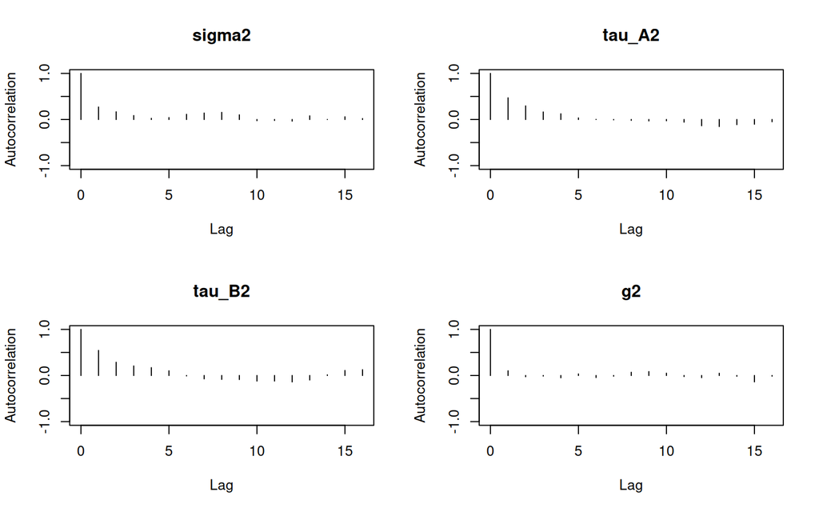

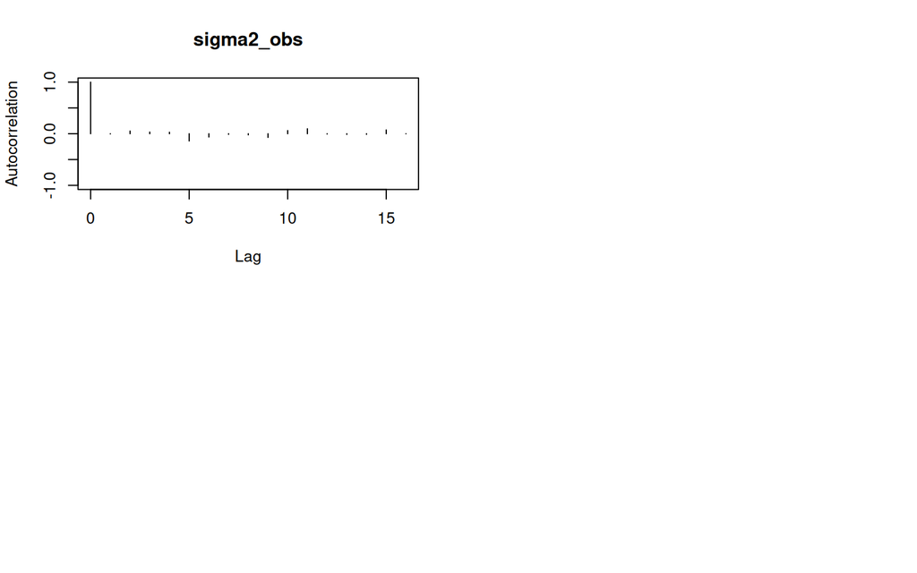

```r
# 3. The course's MCMC habit, DBN edition: ESS + Geweke per parameter
check_convergence(fit_dbn)
```

Read the fevd line the var-literacy way: actor 1’s own shocks carry 0.72 of the 1→2 tie’s forecast-error variance three periods out, and no other actor carries more than 0.05; contractive dynamics again, from a different angle. And read `check_convergence()` honestly: at our classroom settings (800 scans) it rightly flags every variance parameter’s effective sample size as too low: the same verdict `ess()` would give a 30-second `lame` fit. Classroom settings demonstrate; publication runs use more scans, and this checker is how you know when you are there. Also in the package, same pattern, not run here: `plot_trace()` (the traceplots behind that table), `gof()` + `plot_ppc_density()` (posterior-predictive checks, Day 2’s discipline), and `dbn_boot_intervals()` (frequentist intervals for the ALS engine).

# 12 The frontier: Influence: Who moves whom

Everything this week modeled *tie formation*, who connects to whom, and why. Social influence regression (SIR; Minhas & Hoff 2026, *Political Analysis*) asks a different question: **who moves whom**. You have a directed network observed repeatedly, say monthly counts of conflictual events, and the defining feature of that data is that what an actor does next depends on what the whole network did last period. SIR regresses the current network on a lagged signal $X_t$ through a pair of influence matrices:

$$\eta_{ijt} = \theta^\top z_{ijt} + (A\, X_t\, B^\top)_{ij},
\qquad A = \textstyle\sum_r \alpha_r W_r,\quad
B = \textstyle\sum_r \beta_r W_r .$$

$A$ is sender-side influence (how strongly $k$’s past behavior shapes $i$’s future *outgoing* ties), $B$ is receiver-side. The trick that makes this estimable, you cannot fit $2m^2$ free influence weights from one panel, is to parameterize the influence matrices by *observed* covariates $W_r$ (alliance, proximity, shared membership). So instead of asking a latent space to tell you who is influential, you estimate two short coefficient vectors that say *which observable features carry influence*. The reach-for-it question: which observable features make actors influential over time, and on whom?

This fit takes about two seconds.

```r
library(sir)   # remotes::install_github("netify-dev/sir")

dat <- sim_sir(m = 20, T_len = 120, p = 2, q = 2,
               family = "poisson", gain = 0.9, seed = 42)
fit_sir <- cache_fit("fit_sir_frontier", sir(
  dat$Y, W = dat$W, X = dat$X, Z = dat$Z,
  family = "poisson", seed = 6886
))
```

```r
ci <- confint(fit_sir)      # Cluster-robust by default
sir_tbl <- data.frame(
  term  = names(coef(fit_sir)),
  est   = round(unname(coef(fit_sir)), 3),
  lo    = round(ci[, 1], 3),
  hi    = round(ci[, 2], 3),
  truth = round(c(dat$theta, dat$alpha[-1], dat$beta), 3),
  row.names = NULL
)
sir_tbl
```

| term | est | lo | hi | truth |
| --- | --- | --- | --- | --- |
| (Z) Z1 | 0.237 | 0.231 | 0.243 | 0.237 |
| (Z) Z2 | -0.362 | -0.372 | -0.352 | -0.365 |
| (alphaW) W2 | 0.410 | 0.401 | 0.419 | 0.411 |
| (betaW) W1 | -0.654 | -0.660 | -0.648 | -0.651 |
| (betaW) W2 | 0.417 | 0.408 | 0.426 | 0.418 |

On simulated data where we know the truth, recovery is essentially exact, the largest gap between estimate and truth in that table is 0.003. Two reads matter. First, the fitted influence matrix names names:

```r
# The influence matrix's [i, k] entry: Source k's pull on actor i's
# future outgoing ties. (`fr_A` here; plain `A` is this morning's rebels.)
fr_A <- fit_sir$A; diag(fr_A) <- NA
top <- base::order(abs(fr_A), decreasing = TRUE, na.last = NA)[1:5]
cells <- arrayInd(top, dim(fr_A))
data.frame(source = cells[, 2], influenced = cells[, 1],
           weight = round(fr_A[top], 2))
```

| source | influenced | weight |
| --- | --- | --- |
| 14 | 5 | -3.32 |
| 2 | 15 | -2.90 |
| 1 | 15 | -2.70 |
| 1 | 5 | 2.62 |
| 1 | 14 | -2.57 |

Second, you can ask how much of the fitted network’s predicted activity is carried by the lagged channel, as a model-based ablation:

```r
mu_full <- predict(fit_sir)
mu_off  <- predict(fit_sir, newdata = list(
  W = dat$W, X = array(0, dim = dim(dat$X)), Z = dat$Z))
```

With the influence channel zeroed out, mean predicted activity falls from 1.55 to 1.1, the lagged-influence mechanism accounts for about 29% of predicted counts here. This is a comparison between two predictions from the fitted model. It is not a causal intervention effect unless the temporal and exogeneity assumptions in the identification box below are defensible.

**ImportantWhere SIR sits on the map**

SIR deliberately has **no contemporaneous latent term**. Influence enters only through the lagged state; within-period reciprocity and degree heterogeneity stay in the residuals, guarded by cluster-robust standard errors. That is a map decision, stated by the authors in exactly the vocabulary of this course: use SIR when residual dependence is a *nuisance* to guard against, and a latent-variable model when it is *part of the question*. And the guard is not decorative, on the package’s bundled icews application, the cluster-robust standard errors run an order of magnitude wider than the naive ones. That is Day 6’s dyadic-robust lesson, live in a published model.

**NoteThe Day 3 rhyme, in miniature**

The bilinear scale is not identified, $(c\alpha,\, \beta/c)$ gives the same likelihood for any $c \neq 0$, so the package pins $\alpha_1 = 1$ and the invariant object is $C = \alpha\beta^\top$. The same identification-by-convention move as procrustes on Day 3, small enough to see whole. One caution the authors state plainly: “influence” here is conditional temporal association; it earns causal language only when the design does (temporal ordering, exogenous $W$ and $Z$, no unmeasured confounders), Day 6’s rules apply.

**NoteThe full SIR toolbox (optional self-study)**

None of this is part of the core path; all of it runs against the cached fit. `sir` ships the standard applied surface; broom methods, three flavors of uncertainty, out-of-sample checks, and a plot:

```r
# The broom trio: tidy() rows are exactly the shape the payoff
# section's _compare_helpers.R pattern wants; augment() is the
# per-dyad frame (fitted values + Pearson residuals) behind any
# residual map you would draw
sir::tidy(fit_sir)
```

| term | component | estimate | std.error | statistic | p.value |
| --- | --- | --- | --- | --- | --- |
| (Z) Z1 | theta | 0.2374254 | 0.0028342 | 83.77016 | 0 |
| (Z) Z2 | theta | -0.3617677 | 0.0047938 | -75.46649 | 0 |
| (alphaW) W2 | alpha | 0.4097317 | 0.0042275 | 96.91999 | 0 |
| (betaW) W1 | beta | -0.6540213 | 0.0029166 | -224.24289 | 0 |
| (betaW) W2 | beta | 0.4166543 | 0.0043674 | 95.40066 | 0 |

```r
sir::glance(fit_sir)[, c("nobs", "n_periods", "AIC", "converged")]
```

| nobs | n_periods | AIC | converged |
| --- | --- | --- | --- |
| 45600 | 120 | 122295.1 | TRUE |

```r
head(sir::augment(fit_sir), 3)
```

|  | sender | receiver | time | .observed | .fitted | .resid | .resid_pearson |
| --- | --- | --- | --- | --- | --- | --- | --- |
| 2 | 2 | 1 | 1 | 2 | 0.6629741 | 1.3370259 | 1.6420694 |
| 3 | 3 | 1 | 1 | 2 | 2.1622159 | -0.1622159 | -0.1103173 |
| 4 | 4 | 1 | 1 | 3 | 0.6264633 | 2.3735367 | 2.9988043 |

```r
# Day 6's naive-vs-cluster comparison, as one cbind: lower bounds
# side by side. On this clean simulation they barely differ; on the
# package's ICEWS application the cluster-robust intervals run an
# order of magnitude wider (the callout above), so ALWAYS look
round(cbind(cluster = confint(fit_sir)[, 1],
            naive   = confint(fit_sir, se.type = "classical")[, 1]), 3)
```

```
#>             cluster  naive
#> (Z) Z1        0.231  0.230
#> (Z) Z2       -0.372 -0.369
#> (alphaW) W2   0.401  0.401
#> (betaW) W1   -0.660 -0.660
#> (betaW) W2    0.408  0.409
```

```r
# A third route to the same uncertainty: Block bootstrap over time,
# refitting the whole pipeline each draw (~15s cold, cached after)
bs <- cache_fit("sir_boot",
                boot_sir(fit_sir, R = 25, type = "block", seed = 6886))
round(cbind(analytic_se = sir::tidy(fit_sir)$std.error,
            block_boot_se = bs$se), 4)
```

```
#>             analytic_se block_boot_se
#> (Z) Z1           0.0028        0.0042
#> (Z) Z2           0.0048        0.0041
#> (alphaW) W2      0.0042        0.0045
#> (betaW) W1       0.0029        0.0030
#> (betaW) W2       0.0044        0.0039
```

```r
# Honest out-of-sample: Rolling-origin cross-validation against a
# carry-forward baseline, then a genuine one-step forecast
cv <- cv_sir(fit_sir, initial = 110, horizon = 1)
round(cv$aggregate[c("rmse", "naive_rmse")], 2)
```

```
#>       rmse naive_rmse
#>       1.19       2.58
```

```r
fc1 <- forecast(fit_sir, h = 1, Z_future = dat$Z[, , , 120, drop = FALSE])
round(mean(fc1, na.rm = TRUE), 2)   # Mean predicted activity, period 121
```

```
#> [1] 1.52
```

The two lines worth a sentence each: the bootstrap and sandwich SEs never sit more than 0.0014 apart, negligible against coefficients this sharply estimated, so three uncertainty routes (sandwich, classical, bootstrap) deliver one verdict, the sign of a well-specified simulation, and the cross-validated rmse of 1.19 against the naive carry-forward’s 2.58 says the influence structure roughly halves one-step forecast error, which is the out-of-sample version of the switch-off ablation above.

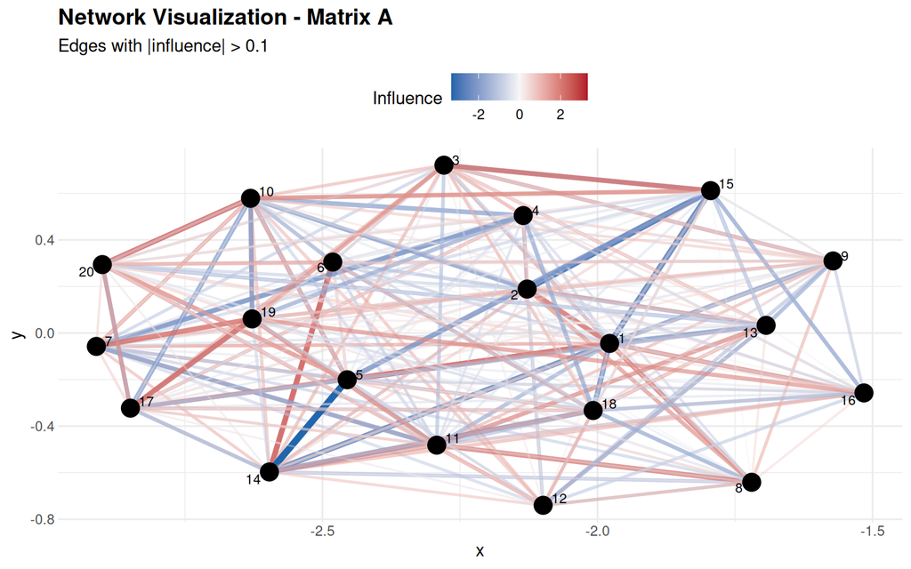

plot_sir_network(fit_sir, matrix = ‘A’): The fitted sender-side influence matrix as a network. Edge color shows the sign and strength of who moves whom. Setting matrix = ‘B’ draws the receiver side.

```r
plot_sir_network(fit_sir, matrix = "A")
```

# 13 The frontier: multilayer and bipartite networks

Everything today was one relation on one actor set. Two relaxations you will hit within a year of doing this for real, and the course’s own data tool already handles both.

**Multilayer**: the same actors, several relations at once. Conflict *and* trade; friendship *and* advice; four event types from a machine-coded stream. `netify` stacks layers into one object in about five seconds:

```r
data(icews, package = "netify")
ic10 <- icews[icews$year == 2010, ]
lay_names <- c("verbCoop", "matlCoop", "verbConf", "matlConf")
layers <- lapply(lay_names, function(v)
  netify(ic10, actor1 = "i", actor2 = "j", symmetric = FALSE,
         weight = v))
ml <- layer_netify(layers, layer_labels = lay_names)
dim(ml)
```

```
#> [1] 152 152   4
```

```r
summary(ml)[, c("layer", "num_actors", "density", "num_edges")]
```

| layer | num_actors | density | num_edges |
| --- | --- | --- | --- |
| verbCoop | 152 | 0.4346462 | 9976 |
| matlCoop | 152 | 0.0927588 | 2129 |
| verbConf | 152 | 0.1110579 | 2549 |
| matlConf | 152 | 0.1155891 | 2653 |

One object, 4 layers, and the summary already shows the substantive hook: verbal cooperation is dense (0.43) while material conflict is sparse (0.12). These are different relations on the same actors, but the density gap is a description, not yet evidence that talk substitutes for action. Event categories can differ in reporting rates, exposure, scale, and the number of opportunities to be observed.

One simple cross-layer diagnostic is tie overlap. Here `edge_threshold = 0` reduces every count layer to “at least one recorded event” versus none, and Jaccard similarity asks how often two layers put a tie on the same dyad:

```r
layer_overlap <- compare_networks(
  ml, method = "jaccard", edge_threshold = 0, return_details = TRUE
)
round(layer_overlap$details$jaccard_matrix, 2)
```

```
#>          verbCoop matlCoop verbConf matlConf
#> verbCoop     1.00     0.20     0.24     0.24
#> matlCoop     0.20     1.00     0.30     0.33
#> verbConf     0.24     0.30     1.00     0.39
#> matlConf     0.24     0.33     0.39     1.00
```

That matrix can establish overlap. It cannot establish substitution, complementarity, or cross-layer influence. Before comparing layers, verify the same actor universe and ordering, the same direction convention, compatible missing-data rules, the same observation window, and a defensible way to make the weights comparable. Otherwise the layer label is mixed up with a change in measurement.

Everything in the course can be fit layer by layer, and Day 3’s trade exercise was quietly an example of that move. Separate fits estimate a pattern for each relation; they do not estimate dependence between relations. The frontier proper uses a joint model when cross-layer dependence is the question: multilayer ERGMs, and multilinear or tensor extensions of the factor model (Hoff’s `amen` line of work generalizes to exactly this). The entry-point survey is Kivelä et al. (2014).

**Bipartite**: two *kinds* of nodes, with ties only across kinds: students and classrooms, groups and events, states and treaties. The classic trap is projecting to one mode (“two states tie if they share a treaty”) and then marveling at the transitivity: **projection manufactures triangles mechanically**, and every one-mode method will dutifully “find” the structure the projection invented. Keep the two-mode shape:

```r
set.seed(6886)
aff <- matrix(rbinom(15 * 6, 1, 0.3), nrow = 15, ncol = 6,
              dimnames = list(paste0("group", 1:15),
                              paste0("forum", 1:6)))
bp <- netify(aff, mode = "bipartite")
summary(bp)[, c("num_row_actors", "num_col_actors", "density")]
```

| num_row_actors | num_col_actors | density |
| --- | --- | --- |
| 15 | 6 | 0.3 |

`ergm` fits bipartite networks natively (the `b1*`/`b2*` term families; Wang, Sharpe, Robins & Pattison 2009 is the standard treatment, building on Skvoretz & Faust 1999’s founding p* work), `lame` handles rectangular relational data through its bipartite mode, and day 4’s GOF discipline transfers unchanged.

# 14 The frontier: Scale, and the adjacent field

**What breaks when n gets big.** Every likelihood today touched all $O(n^2)$ dyads per iteration, and the MCMC-based fits did it thousands of times. The rough, honest speed limits as of now, as a map rather than a lecture:

| Family | Comfortable $n$ | What breaks first | The escape hatch |
| --- | --- | --- | --- |
| Descriptives, community detection | Millions | Very little; built for this | None needed |
| Variational SBM (`blockmodels`; graph-tool) | $10^4$–$10^6$ | Memory on dense graphs | Sparse storage; the peixoto MCMC line |
| SRM / AME / latent space (`lame`, `amen`) | A few thousand | Memory, the $n \times n$ objects, not the per-step math | **Case-control approximate likelihood** (Raftery, Niu, Hoff & Yeung 2012): keep all the ties, sample the zeros, $O(n^2)$ toward $O(n)$ per sweep |
| ERGM MCMC-mle | Low thousands | MCMC mixing and degeneracy | Block-structured “local dependence” ERGMs: `bigergm` (the Schweinberger–Handcock idea; dependence within communities, not across them) |

The general recipe when you outgrow a tool: subsample the zeros, exploit blocks, or coarsen the model, in that order of regret.

**The adjacent field.** Machine learning treats the same adjacency matrices with different goals: node embeddings (node2vec; Grover & Leskovec 2016) and graph neural networks (Hamilton, Ying & Leskovec 2017 is the survey to start with) are optimized for *prediction*; link prediction, node classification, at scales none of this week’s models reach. What they do not ship is what this course was about: calibrated uncertainty, identified parameters, and an interpretable account of dependence. An embedding is Day 3’s latent space with the inferential guarantees traded for scale and flexibility; if your deliverable is a coefficient with an honest interval, stay on this side of the fence; if it is top-k link prediction on ten million nodes, go visit, and bring Day 3’s procrustes skepticism with you when you interpret the axes.

# 15 The frontier: The econometrics of networks

Everything this week put dependence in random or latent structure. A parallel literature in economics puts it in fixed effects instead - degree heterogeneity as incidental parameters to be conditioned out (Graham’s tetrad logit), bias-corrected (fernández-val & weidner), or absorbed in two-way gravity terms and estimated by ppml, with dyadic-robust standard errors doing the calibration work our latent terms do. It is robust where we assume exogeneity, and silent where we measure. Day 1’s map called this the other honest bet on the same problem; Day 6’s dyadic cluster-robust errors are the same estimator family wearing their flag. If you are headed toward econ-adjacent seminars, this is the dialect they speak, and the DCR errors from day 6 are your passport.

**Where to start** (all on the shelf below): de Paula (2017) is the doorway survey; Graham (2017, *Econometrica*) is the fe philosophy executed on a binary network start to finish; de Paula (2020, *annual review of economics*) is the shorter, more current formation survey if you want a second pass.

# 16 Close: The map, filled in

Day 1 promised that every cell of this table would get filled. Here it is, one last time, with today’s column added:

| where the dependence goes | method | day | what it said on the rebel network |
| --- | --- | --- | --- |
| describe it | centrality, communities | wk 0 / 1 | two hubs, ideological bunching |
| latent effects (additive) | SRM | 2 | actor variance is first-class; homophily sharpens |
| latent effects (discrete) | stochastic blockmodel | 2 | kinds? mostly no; thin two-hub core vs. periphery |
| latent effects (geometry) | latent factor / AME | 3 | mixed-sign geometry, concentrated on the same two hubs |
| the model (structure) | ERGM | 4 | ‘closure’ was hub costume; given sociality(), the family agrees |
| across time (waves) | SAOM / TERGM | 5 / 4 | not askable: single snapshot |
| across time (events) | REM (today’s frontier) | 7 | (different data: call-backs within seconds, inertia dominates) |
| the standard errors | dcr + causal design | 6 | same estimates, honestly wider intervals |

And the honest ending: three seams in this field are open research questions, and you now know enough to read them as live arguments rather than settled doctrine.

- **ERGM versus latent variables.** Day 4 versus Days 2–3. Both families survive GOF on different networks (you watched each win one this week); there is no theorem that picks a side a priori, and the literature’s actual practice; Cranmer & Desmarais (2011) on one flank, Minhas, Hoff & Ward (2019) on the other; is a running argument about whether structure should be tested or absorbed. I am an author on one side of this; discount me accordingly.
- **AME versus robust-variance inference.** Day 3 versus Day 6. Carlson, Incerti & Aronow (2024) exclude AME-style models from their census *by name* (their footnote 5); “taking dyads seriously” dismisses se-adjustment without running the cluster-robust comparator. Those two readings therefore do not provide a controlled head-to-head under conditions where we know the truth. A current literature search should come before any novelty claim, but the comparative design remains worth doing. I am on both sides of this seam, which is why I do not treat either reading as the last word.
- **SAOM versus TERGM versus REM.** Days 4 and 5, and today’s demo. The TERGM–SAOM exchange conceded its coding error, still disputes what the corrected comparison shows, and left its methodological question open; and underneath both, the REM quietly asks whether your waves were ever real. The event-level view is the youngest of the three and moving fastest (Bianchi et al. 2024 is the survey).

**What to read next, per family**: one entry point each, chosen so the next step is never “the literature”:

[output not shown]

**NoteWhat today deliberately did not show, and where it lives**

- **Each family’s native one-call GOF**: `lame`’s `gof_plot(fit, statistics = ...)`, `ergm`’s `gof()` + `plot()`, RSiena’s `sienaGOF()`. Today ran everything through the shared `calc_gof()` yardstick on purpose, so the lenses were comparable; the native versions are demonstrated on Days 2, 4, and 5 respectively, and they are what you would use inside a single family.
- **DCR’s `coeftest()` one-liner** for a publication-style table from the robust variance; Day 6’s assignment owns it; today’s `tab_dcr` build is the transparent version of the same arithmetic.
- **A fitted SAOM/TERGM on today’s data**: not an omission, an impossibility (single snapshot; the payoff table says “not askable”). Your HW 4 `sienaFit` objects plug into `row_saom()` in `_compare_helpers.R`, on the estimand terms stated loudly in that file.
- **The rest of the DBN and SIR surfaces**: `plot_trace()`, `gof()`, `plot_ppc_density()`, `dbn_boot_intervals()`; residual maps built from `augment()`’s per-dyad frame, and multi-step `forecast()` paths; named in the two toolbox asides, worked end to end in the package vignettes (`vignette("methodology", "dbn")`, `vignette("sir_overview", "sir")`).

## 16.1 After the Models Run: Write the Political Science Paragraph

The capstone is not finished when the comparison table is full. It is finished when a reader can understand why the estimates change the political argument. A strong final paragraph has five parts:

1. **Question:** State the political quantity or mechanism the analysis is trying to learn about.
2. **Model choice:** Explain why the primary model represents the dependence, time, and actor roles that matter for that question.
3. **Substantive result:** Describe the politically meaningful pattern, actor comparison, predicted probability, or mechanism comparison. Do not march through every coefficient.
4. **Diagnostic:** Name the fit, sensitivity, convergence, or design evidence that makes the interpretation credible.
5. **Limit and flip condition:** State what the model does not establish and what empirical result would move you to the runner-up model or change the conclusion.

**TipA human version of the capstone result**

“The apparent closure in rebel cooperation weakens once persistent differences in groups’ willingness to initiate and receive cooperation are represented. The AME and ERGM comparisons both point toward substantial group-level sociality rather than a generic triangle-closing process, and the relevant simulated degree patterns are consistent with that interpretation. This does not show that sociality causes cooperation, and evidence that an ERGM uniquely reproduces held-out shared-partner structure would move us back toward an explicit closure account.”

That paragraph is more useful than declaring one model the winner. It connects an estimand to a political explanation, makes clear which patterns carry the conclusion, and gives the reader a concrete way to disagree. Advanced methods earn their place when they sharpen the substantive claim and its limits, not when they merely make the methods section longer.

# 17 Your turn

**TipExercises**

**1. (Required: the framework, on your data.)** If you posted your one-sentence branch + runner-up during the framework segment, you have already started this; upgrade the sentence to the paragraph below. Take the dataset you care about: the one you came to ICPSR with. Walk it through Section 9 out loud: which branch is your question on? Write **one paragraph** justifying a model choice and, this is the required part, name the *runner-up* model and the observation or diagnostic that would flip you to it. If you did not bring data, use `netify`’s `classroom_edges`/`classroom_nodes` (friendship among students) or today’s rebel network with a fresh question.

**2. (Stretch: Two rivals, reconciled.)** Actually fit your chosen model *and* the runner-up on your data (or on the rebel network: reproduce Section 7’s `erg_soc` from a cold cache and set it against the AME from Section 6). Extract one comparable claim from each: a coefficient verdict, a GOF band, a recovered structure, and write three sentences reconciling them in the payoff-table style: what question did each answer, and do the *answers* actually conflict once you say the questions out loud?

**3. (Your data, forward-looking.)** Which frontier method from today is closest to a dataset you expect to have within two years, and what is the first sentence of its entry-point reading? (Yes, this requires opening the reading. That is the point.)

**Guidance: Open after you’ve tried them**

```r
## 1. ---------------------------------------------------------------
# There is no answer key for your data, but here is the paragraph
# pattern, worked for the course's alliance network (Day 3):
#   "My question is whether shared democracy predicts alliance ties,
#    with dependence as a nuisance -> honest-beta branch. The network
#    is binary, symmetric, one snapshot -> SRM/AME (lame, family =
#    'binary', symmetric = TRUE). Runner-up: ERGM with edge covariates,
#    because if gof shows the AME's latent space absorbing what is
#    really a closure mechanism among democracies, the ERGM's testable
#    triangle term becomes the more honest tool. The diagnostic that
#    would flip me: simulate from the fitted AME and check whether
#    democracy-triangles specifically (not triangles generally) are
#    under-reproduced."
# Grade yourself on: (a) Named branch, (b) Named runner-up,
# (c) A *specific, runnable* flip condition, not "if it fits badly."

## 2. ---------------------------------------------------------------
# On the rebel network the reconciliation is already on screen in
# section 7: erg_soc collapses gwesp to ~0.18 and covers both yardstick
# statistics. Reproduce it from a cold cache and notice two things
# while you do:
#   (a) The spec drops the nodal covariates on purpose. sociality()
#       absorbs every nodal main effect, so keeping nodecov() terms
#       makes the model nonidentifiable; ERGM will warn about
#       singularities, and the warning is correct, not a bug.
#   (b) The three payoff-style sentences you are after: The AME said
#       "No residual closure once actors have effects"; the ERGM,
#       handed actor effects of its own, says the same; the two
#       families only looked like rivals while the ERGM was missing a
#       term. Answers conflict far less often than specifications do.

## 3. ---------------------------------------------------------------
# No code. But if you cannot name the dataset, that is information too:
# It means your next-two-years questions live in the cells the course
# already covered, and the frontier can wait. Also fine.
```

# 18 Reading

The day’s working citations, in order of appearance:

- Gade, Gabbay, Hafez & Kelly (2019), “Networks of cooperation: rebel alliances in fragmented civil wars,” *Journal of Conflict Resolution* 63(9):2071–2097: the data every lens pointed at today.
- Carlson, Incerti & Aronow (2024), “Dyadic clustering in international relations,” *Political Analysis* 32(2):186–198: the se-inflation census behind lens 0 (and Day 6).
- Butts (2008), “A relational event framework for social action,” *Sociological Methodology* 38(1):155–200: the REM’s founding paper; `relevent` is its software.
- Stadtfeld & Block (2017), “Interactions, actors, and time: dynamic network actor models for relational events,” *Sociological Science* 4:318–352: the actor-oriented event model; `goldfish` is its software.
- Bianchi, Filippi-Mazzola, Lomi & Wit (2024), “Relational event modeling,” *Annual Review of Statistics and Its Application* 11:297–319: the current REM survey.
- Leifeld & Cranmer (2019), *Network Science* 7(1):20–51; Block, Hollway, Stadtfeld, Koskinen & Snijders (2022) and Leifeld & Cranmer (2022), both *Network Science* 10(1): the TERGM–SAOM exchange behind the close’s third open seam (Day 5 walked the dispute; the ancillary TERGM deep dive walks the papers piece by piece); read all three in order or none.
- Hoff (2015), “Multilinear tensor regression for longitudinal relational data,” *Annals of Applied Statistics* 9(3):1169–1193; the paper that made your three-way array a first-class object; the tensor lane’s foundation.
- Chen, Xiao & Yang (2021), “Autoregressive models for matrix-valued time series,” *Journal of Econometrics* 222(1):539–560: the time-series side of the same bilinear idea; `dbn`’s `static` model is exactly this. (The DBN methods paper, Salau & Minhas, is under review: the package and its vignettes are the public artifact.)
- Minhas & Hoff (2026), “Decomposing network influence: social influence regression,” *Political Analysis* 34(2):217–236: the influence estimand, with the covariate-parameterized bilinear trick that makes it identifiable from one panel; `sir` is its software.
- Kivelä, Arenas, Barthelemy, Gleeson, Moreno & Porter (2014), “Multilayer networks,” *Journal of Complex Networks* 2(3):203–271.
- Wang, Sharpe, Robins & Pattison (2009), “Exponential random graph (p*) models for affiliation networks,” *Social Networks* 31(1):12–25; Skvoretz & Faust (1999), “Logit models for affiliation networks,” *Sociological Methodology* 29: the founding p* treatment.
- Raftery, Niu, Hoff & Yeung (2012), “Fast inference for the latent space network model using a case-control approximate likelihood,” *Journal of Computational and Graphical Statistics* 21(4):901–919.
- Grover & Leskovec (2016), “Node2vec: scalable feature learning for networks,” *KDD 2016*; Hamilton, Ying & Leskovec (2017), “Representation learning on graphs: methods and applications,” *IEEE Data Engineering Bulletin* 40(3):52–74.
- de Paula (2017), “Econometrics of network models,” in *Advances in Economics and Econometrics: Eleventh World Congress*, ch. 8, 268–323: the doorway into the econometrics-of-networks lane; de Paula (2020), “Econometric models of network formation,” *Annual Review of Economics* 12:775–799 is the shorter, more current second pass.
- Graham (2017), “An econometric model of network formation with degree heterogeneity,” *Econometrica* 85(4):1033–1063; fixed effects conditioned out of a binary network via tetrad logit; read it next to Day 3 and feel the two traditions pull.
- Plus the per-family “read next” table in Section 16, which is the reading list that matters after this week.